# Comparing Sports Primes: Analysis of Peak Performance Across Major American Sports

This notebook analyzes the "prime" years of athletes across three major American sports: MLB, NFL, NBA.

## Project Overview

We'll examine when athletes reach their peak performance by analyzing historical data from players who played for 15 years.

## Defining "Prime"

The period of time in a sports player's career when they play their best, statistically.

**Note:** There will be outliers with Hall of Famers and players who play longer than average. The average player in all major sports has a significantly shorter career than the average starting lineup player.

Here is the link to the Github pages website : https://zaji-l.github.io/Comparing_Sports_Primes/

# Colloboration Plan

```python
##%%shell
##jupyter nbconvert --to html sports_primes_analysis_working.ipynb
```

## Setup and Imports

```python
!git clone https://github.com/Zaji-L/Comparing_Sports_Primes

%cd Comparing_Sports_Primes

!ls
```

```
Cloning into 'Comparing_Sports_Primes'...
remote: Enumerating objects: 108, done.
remote: Counting objects: 100% (108/108), done.
remote: Compressing objects: 100% (102/102), done.
remote: Total 108 (delta 51), reused 19 (delta 6), pack-reused 0 (from 0)
Receiving objects: 100% (108/108), 12.26 MiB | 5.95 MiB/s, done.
Resolving deltas: 100% (51/51), done.
/content/Comparing_Sports_Primes/Comparing_Sports_Primes/Comparing_Sports_Primes/Comparing_Sports_Primes/Comparing_Sports_Primes/Comparing_Sports_Primes/Comparing_Sports_Primes/Comparing_Sports_Primes/Comparing_Sports_Primes
all_seasons.csv		   Game_Logs_Wide_Receiver_and_Tight_End.csv
Basic_Stats.csv		   index.html
Batting.csv		   Master.csv
Game_Logs_Quarterback.csv  README.md
Game_Logs_Runningback.csv  sports_primes_analysis_working.ipynb
```

```python
import pandas as pd
import numpy as np
import matplotlib.pyplot as plt
import seaborn as sns
import warnings
warnings.filterwarnings('ignore')

# Set up plotting style
plt.style.use('seaborn-v0_8')
sns.set_palette("husl")
plt.rcParams['figure.figsize'] = (12, 8)

print("Libraries imported successfully!")
```

```
Libraries imported successfully!
```

# Data Collecion and Cleaning

First we need to load our data sets

```python
# Load Batting.csv data
print("Loading Batting.csv...")
batting = pd.read_csv('Batting.csv')

print(f"Dataset loaded: {batting.shape[0]:,} rows, {batting.shape[1]} columns")
print(f"Year range: {batting['yearID'].min()} - {batting['yearID'].max()}")
print("\nFirst few rows:")
batting.head()

master = pd.read_csv('Master.csv')
master.head()
```

```
Loading Batting.csv...
Dataset loaded: 101,332 rows, 22 columns
Year range: 1871 - 2015

First few rows:
```

|  | playerID | birthYear | birthMonth | birthDay | birthCountry | birthState | birthCity | deathYear | deathMonth | deathDay | ... | nameLast | nameGiven | weight | height | bats | throws | debut | finalGame | retroID | bbrefID |
| --- | --- | --- | --- | --- | --- | --- | --- | --- | --- | --- | --- | --- | --- | --- | --- | --- | --- | --- | --- | --- | --- |
| 0 | aardsda01 | 1981.0 | 12.0 | 27.0 | USA | CO | Denver | NaN | NaN | NaN | ... | Aardsma | David Allan | 220.0 | 75.0 | R | R | 2004-04-06 | 2015-08-23 | aardd001 | aardsda01 |
| 1 | aaronha01 | 1934.0 | 2.0 | 5.0 | USA | AL | Mobile | NaN | NaN | NaN | ... | Aaron | Henry Louis | 180.0 | 72.0 | R | R | 1954-04-13 | 1976-10-03 | aaroh101 | aaronha01 |
| 2 | aaronto01 | 1939.0 | 8.0 | 5.0 | USA | AL | Mobile | 1984.0 | 8.0 | 16.0 | ... | Aaron | Tommie Lee | 190.0 | 75.0 | R | R | 1962-04-10 | 1971-09-26 | aarot101 | aaronto01 |
| 3 | aasedo01 | 1954.0 | 9.0 | 8.0 | USA | CA | Orange | NaN | NaN | NaN | ... | Aase | Donald William | 190.0 | 75.0 | R | R | 1977-07-26 | 1990-10-03 | aased001 | aasedo01 |
| 4 | abadan01 | 1972.0 | 8.0 | 25.0 | USA | FL | Palm Beach | NaN | NaN | NaN | ... | Abad | Fausto Andres | 184.0 | 73.0 | L | L | 2001-09-10 | 2006-04-13 | abada001 | abadan01 |

5 rows × 24 columns

Then we need to find players with 15 year careers.

```python
# Find players with exactly 15-year careers
print("Identifying players with 15-year careers...")

# Count number of seasons for each player
career_lengths = batting.groupby('playerID')['yearID'].nunique()

# Get players with exactly 15 years
players_15_years = career_lengths[career_lengths == 15].index.tolist()
print(f"Found {len(players_15_years)} players with exactly 15-year careers")

# Aggregate stats by player-year (some players played for multiple teams in a season)
batting_15 = batting[batting['playerID'].isin(players_15_years)].copy()
batting_15_agg = batting_15.groupby(['playerID', 'yearID']).agg({
    'G': 'sum',
    'AB': 'sum',
    'H': 'sum',
    'R': 'sum',
    'HR': 'sum',
    'RBI': 'sum'
}).reset_index()

# Filter for regular players (at least 100 AB per season on average)
player_avg_ab = batting_15_agg.groupby('playerID')['AB'].mean()
regular_players = player_avg_ab[player_avg_ab >= 100].index.tolist()

print(f"Found {len(regular_players)} regular players (avg >= 100 AB/season) with 15-year careers")

# Filter to regular players only
batting_regular = batting_15_agg[batting_15_agg['playerID'].isin(regular_players)].copy()

# Verify all have exactly 15 seasons
player_season_counts = batting_regular.groupby('playerID').size()
print(f"All players have exactly 15 seasons: {(player_season_counts == 15).all()}")
print(f"\nTotal player-seasons in analysis: {len(batting_regular)}")
print(f"Number of players: {batting_regular['playerID'].nunique()}")
```

```
Identifying players with 15-year careers...
Found 270 players with exactly 15-year careers
Found 165 regular players (avg >= 100 AB/season) with 15-year careers
All players have exactly 15 seasons: True

Total player-seasons in analysis: 2475
Number of players: 165
```

Now we need to calculate our performance metrics for later use in visulizations.

```python
# Calculate career year (1-15) and performance metrics
print("Calculating career year and performance metrics...")

# Sort by player and year, then add career year counter
batting_regular = batting_regular.sort_values(['playerID', 'yearID'])
batting_regular['career_year'] = batting_regular.groupby('playerID').cumcount() + 1

# Calculate hits per at-bat
batting_regular['hits_per_ab'] = batting_regular['H'] / batting_regular['AB']

# Remove any rows with 0 at-bats (edge case)
batting_regular = batting_regular[batting_regular['AB'] > 0]

print(f"Final dataset: {len(batting_regular)} player-seasons")
print("\nSample data:")
print(batting_regular[['playerID', 'yearID', 'career_year', 'AB', 'H', 'hits_per_ab']].head(15))

# Calculate statistics by career year
print("\n" + "="*60)
print("Average Performance by Career Year")
print("="*60)
avg_by_career_year = batting_regular.groupby('career_year')['hits_per_ab'].agg(['mean', 'std', 'count'])
print(avg_by_career_year)

# Identify peak performance
peak_year = avg_by_career_year['mean'].idxmax()
peak_value = avg_by_career_year['mean'].max()
print(f"\n*** Peak Performance: Career Year {peak_year} (Hits/AB: {peak_value:.4f}) ***")
```

```
Calculating career year and performance metrics...
Final dataset: 2474 player-seasons

Sample data:
     playerID  yearID  career_year     AB      H  hits_per_ab
0   ainsmed01    1910            1  104.0   20.0     0.192308
1   ainsmed01    1911            2  149.0   33.0     0.221477
2   ainsmed01    1912            3  186.0   42.0     0.225806
3   ainsmed01    1913            4  229.0   49.0     0.213974
4   ainsmed01    1914            5  151.0   34.0     0.225166
5   ainsmed01    1915            6  120.0   24.0     0.200000
6   ainsmed01    1916            7  100.0   17.0     0.170000
7   ainsmed01    1917            8  350.0   67.0     0.191429
8   ainsmed01    1918            9  292.0   62.0     0.212329
9   ainsmed01    1919           10  364.0   99.0     0.271978
10  ainsmed01    1920           11  186.0   43.0     0.231183
11  ainsmed01    1921           12  160.0   45.0     0.281250
12  ainsmed01    1922           13  379.0  111.0     0.292876
13  ainsmed01    1923           14  273.0   58.0     0.212454
14  ainsmed01    1924           15    5.0    3.0     0.600000

============================================================
Average Performance by Career Year
============================================================
                 mean       std  count
career_year
1            0.250550  0.124635    164
2            0.253092  0.080068    165
3            0.262645  0.053813    165
4            0.270897  0.042479    165
5            0.272019  0.036001    165
6            0.270558  0.043849    165
7            0.272919  0.042523    165
8            0.275348  0.036718    165
9            0.272135  0.038108    165
10           0.272273  0.035092    165
11           0.265784  0.039921    165
12           0.267896  0.033399    165
13           0.266349  0.070312    165
14           0.250315  0.052544    165
15           0.210662  0.088620    165

*** Peak Performance: Career Year 8 (Hits/AB: 0.2753) ***
```

#### Merging Baseball Datasets

- We need to match the batting data with player ID and age

```python
batting_regular_age = batting_regular.merge(master[['playerID',	'birthYear']], on='playerID')
batting_regular_age['age'] =  batting_regular_age['yearID'] - batting_regular_age['birthYear']
batting_regular_age['age'] = batting_regular_age['age'].astype(int)
batting_regular_age
```

|  | playerID | yearID | G | AB | H | R | HR | RBI | career_year | hits_per_ab | birthYear | age |
| --- | --- | --- | --- | --- | --- | --- | --- | --- | --- | --- | --- | --- |
| 0 | ainsmed01 | 1910 | 33 | 104.0 | 20.0 | 4.0 | 0.0 | 9.0 | 1 | 0.192308 | 1890.0 | 20 |
| 1 | ainsmed01 | 1911 | 61 | 149.0 | 33.0 | 12.0 | 0.0 | 14.0 | 2 | 0.221477 | 1890.0 | 21 |
| 2 | ainsmed01 | 1912 | 61 | 186.0 | 42.0 | 22.0 | 0.0 | 22.0 | 3 | 0.225806 | 1890.0 | 22 |
| 3 | ainsmed01 | 1913 | 84 | 229.0 | 49.0 | 26.0 | 2.0 | 20.0 | 4 | 0.213974 | 1890.0 | 23 |
| 4 | ainsmed01 | 1914 | 62 | 151.0 | 34.0 | 11.0 | 0.0 | 13.0 | 5 | 0.225166 | 1890.0 | 24 |
| ... | ... | ... | ... | ... | ... | ... | ... | ... | ... | ... | ... | ... |
| 2469 | younger01 | 2002 | 138 | 496.0 | 139.0 | 57.0 | 3.0 | 28.0 | 11 | 0.280242 | 1967.0 | 35 |
| 2470 | younger01 | 2003 | 135 | 475.0 | 119.0 | 80.0 | 15.0 | 34.0 | 12 | 0.250526 | 1967.0 | 36 |
| 2471 | younger01 | 2004 | 104 | 344.0 | 99.0 | 55.0 | 1.0 | 27.0 | 13 | 0.287791 | 1967.0 | 37 |
| 2472 | younger01 | 2005 | 56 | 142.0 | 39.0 | 22.0 | 2.0 | 12.0 | 14 | 0.274648 | 1967.0 | 38 |
| 2473 | younger01 | 2006 | 60 | 138.0 | 28.0 | 20.0 | 3.0 | 15.0 | 15 | 0.202899 | 1967.0 | 39 |

2474 rows × 12 columns

#### NFL Dataset

Here, we chose to use only quaterback data, because football has so many positions, each with different statistically categories, we chose the one that is most synonomous with the sport. Similiarly, our MLB stats are based on offensive capabiltiies, and the QB is the face of the offense.  
The process is similar to the MLB dataset, however, here there is far more information in regards to individual players, so that data needs to be cleaned up.  
Here we are also looking for people who had 15 seasons of experience, this dataset makes it much easier for us. Instead of counting repeat instances of a player, we just filter through their 'Experience' column.

```python
NFL_Age = pd.read_csv("Basic_Stats.csv")

# Filter for players with '15' in their Experience column
# Convert 'Experience' to string type to handle potential NaN values safely before using str.contains
NFL_Age = NFL_Age[NFL_Age['Experience'].astype(str).str.contains('15', na=False)]

NFL_Age.drop(columns=['College', 'Current Status', 'Current Team', 'High School', 'High School Location', 'Height (inches)', 'Weight (lbs)', 'Number'], inplace=True)
NFL_Age.head()
```

|  | Age | Birth Place | Birthday | Experience | Name | Player Id | Position | Years Played |
| --- | --- | --- | --- | --- | --- | --- | --- | --- |
| 591 | 44.0 | Camden , SC | 1/7/1973 | 15 Seasons | Engram, Bobby | bobbyengram/2500556 | NaN | 1996 - 2010 |
| 787 | 44.0 | San Jose , CA | 3/22/1973 | 15 Seasons | Nedney, Joe | joenedney/2502269 | NaN | 1996 - 2010 |
| 1349 | 42.0 | Pittsburgh , PA | 12/5/1974 | 15 Seasons | Batch, Charlie | charliebatch/2499567 | NaN | 1998 - 2012 |
| 1466 | NaN | Brooklyn , NY | 4/3/1949 | 15 Seasons | Alzado, Lyle | lylealzado/2508429 | NaN | 1971 - 1985 |
| 1811 | 53.0 | Washington , DC | 6/17/1963 | 15 Seasons | Glover, Kevin | kevinglover/2500819 | NaN | 1985 - 1999 |

This is a much smaller dataset than the MLB, though this can be explained because the MLB is a much older league, with more positions, and its much lower contact than the NBA or the NFL. Thus, we have a smaller set of NFL players.

```python
print(f"Number of entries remaining in NFL_Age: {len(NFL_Age)}")
```

```
Number of entries remaining in NFL_Age: 75
```

Similarly as the MLB data, we are loading the NFL playing data and making sure that the stats that we need are the correct dtypes, which would be either int or float.

```python
#Load data
QB_stats = pd.read_csv("Game_Logs_Quarterback.csv")
QB_stats = QB_stats[QB_stats['Season'].astype(str).str.contains('Regular', na=False)]

print("Available columns in QB_stats:", QB_stats.columns.tolist())

# List of columns that should be numeric and might contain '--'
numeric_cols = [
    'Passes Attempted', 'Passes Completed', 'Passing Yards', 'TD Passes', 'Ints', 'Sacks',
    'Sacked Yards Lost', 'Passer Rating', 'Rushing Attempts', 'Rushing Yards',
    'Rushing TDs', 'Fumbles', 'Fumbles Lost'
]

# Convert these columns to numeric, coercing errors (like '--') to NaN
for col in numeric_cols:
    QB_stats[col] = pd.to_numeric(QB_stats[col], errors='coerce')

# Drop rows where 'Passes Attempted' is NaN, indicating the player likely did not play as QB
QB_stats.dropna(subset=['Passes Attempted'], inplace=True)

print(f"Number of QB entries after filtering for regular season and active play: {len(QB_stats)}")
QB_stats.head()
```

```
Available columns in QB_stats: ['Player Id', 'Name', 'Position', 'Year', 'Season', 'Week', 'Game Date', 'Home or Away', 'Opponent', 'Outcome', 'Score', 'Games Played', 'Games Started', 'Passes Completed', 'Passes Attempted', 'Completion Percentage', 'Passing Yards', 'Passing Yards Per Attempt', 'TD …
Number of QB entries after filtering for regular season and active play: 16375
```

|  | Player Id | Name | Position | Year | Season | Week | Game Date | Home or Away | Opponent | Outcome | ... | Ints | Sacks | Sacked Yards Lost | Passer Rating | Rushing Attempts | Rushing Yards | Yards Per Carry | Rushing TDs | Fumbles | Fumbles Lost |
| --- | --- | --- | --- | --- | --- | --- | --- | --- | --- | --- | --- | --- | --- | --- | --- | --- | --- | --- | --- | --- | --- |
| 19 | billdemory/2512778 | Demory, Bill | NaN | 1973 | Regular Season | 4 | 10/07 | Away | MIA | L | ... | 2.0 | 1.0 | 4.0 | 8.3 | NaN | NaN | -- | NaN | NaN | NaN |
| 20 | billdemory/2512778 | Demory, Bill | NaN | 1973 | Regular Season | 5 | 10/14 | Away | NE | W | ... | 0.0 | 1.0 | 11.0 | 39.6 | 2.0 | 0.0 | 0.0 | 0.0 | NaN | NaN |
| 21 | billdemory/2512778 | Demory, Bill | NaN | 1973 | Regular Season | 6 | 10/21 | Away | PIT | L | ... | 3.0 | 4.0 | 38.0 | 41.4 | 2.0 | -1.0 | -0.5 | 0.0 | NaN | NaN |
| 22 | billdemory/2512778 | Demory, Bill | NaN | 1973 | Regular Season | 7 | 10/28 | Home | DEN | L | ... | 2.0 | 0.0 | 0.0 | 0.0 | NaN | NaN | -- | NaN | NaN | NaN |
| 24 | billdemory/2512778 | Demory, Bill | NaN | 1973 | Regular Season | 9 | 11/11 | Home | NE | W | ... | 1.0 | 1.0 | 9.0 | 59.4 | NaN | NaN | -- | NaN | NaN | NaN |

5 rows × 29 columns

Now, we need to aggregate this data so that it is easier for us to work on because the statistics we are basing this study on is aggregate per season.

```python
# Columns to aggregate by summing
agg_cols = [
    'Passes Completed', 'Passes Attempted', 'Passing Yards', 'TD Passes', 'Ints', 'Sacks',
    'Sacked Yards Lost', 'Rushing Attempts', 'Rushing Yards', 'Rushing TDs', 'Fumbles', 'Fumbles Lost'
]

# Group by Player Id and Year and sum the aggregated columns
QB_season_stats = QB_stats.groupby(['Player Id', 'Year'])[agg_cols].sum().reset_index()

# Recalculate Completion Percentage
QB_season_stats['Completion Percentage'] = (QB_season_stats['Passes Completed'] / QB_season_stats['Passes Attempted']) * 100
QB_season_stats['Completion Percentage'] = QB_season_stats['Completion Percentage'].fillna(0) # Handle cases with 0 attempts

# Recalculate Yards Per Carry
QB_season_stats['Yards Per Carry'] = QB_season_stats['Rushing Yards'] / QB_season_stats['Rushing Attempts']
QB_season_stats['Yards Per Carry'] = QB_season_stats['Yards Per Carry'].fillna(0) # Handle cases with 0 rushing attempts

# Display the first few rows of the aggregated data
print(f"Number of QB season entries: {len(QB_season_stats)}")
display(QB_season_stats.head())
```

```
Number of QB season entries: 2026
```

|  | Player Id | Year | Passes Completed | Passes Attempted | Passing Yards | TD Passes | Ints | Sacks | Sacked Yards Lost | Rushing Attempts | Rushing Yards | Rushing TDs | Fumbles | Fumbles Lost | Completion Percentage | Yards Per Carry |
| --- | --- | --- | --- | --- | --- | --- | --- | --- | --- | --- | --- | --- | --- | --- | --- | --- |
| 0 | a.j.feeley/2504566 | 2001 | 10.0 | 14.0 | 143.0 | 2.0 | 1.0 | 0.0 | 0.0 | 0.0 | 0.0 | 0.0 | 0.0 | 0.0 | 71.428571 | 0.000000 |
| 1 | a.j.feeley/2504566 | 2002 | 86.0 | 154.0 | 1011.0 | 6.0 | 5.0 | 7.0 | 48.0 | 12.0 | 6.0 | 0.0 | 2.0 | 1.0 | 55.844156 | 0.500000 |
| 2 | a.j.feeley/2504566 | 2004 | 191.0 | 356.0 | 1893.0 | 11.0 | 15.0 | 23.0 | 136.0 | 14.0 | 13.0 | 1.0 | 10.0 | 5.0 | 53.651685 | 0.928571 |
| 3 | a.j.feeley/2504566 | 2006 | 26.0 | 38.0 | 342.0 | 3.0 | 0.0 | 1.0 | 10.0 | 1.0 | 3.0 | 0.0 | 1.0 | 1.0 | 68.421053 | 3.000000 |
| 4 | a.j.feeley/2504566 | 2007 | 59.0 | 103.0 | 681.0 | 5.0 | 8.0 | 3.0 | 10.0 | 7.0 | 23.0 | 0.0 | 1.0 | 0.0 | 57.281553 | 3.285714 |

Now we need to merge the two NFL datasets so that we can match age to player and season.

```python
# Merge QB_season_stats with NFL_Age to get birthYear and Age information
# NFL_Age already contains 'Experience' filtered for 15 seasons, but we need individual birthYear
# Let's use the original Basic_Stats.csv to get birth years for all players first, then filter for 15-year careers later.

nfl_basic_stats = pd.read_csv("Basic_Stats.csv")

# Select relevant columns for merging
nfl_player_info = nfl_basic_stats[['Player Id', 'Birthday', 'Experience']].copy()

# Convert 'Birthday' to datetime objects to extract birth year
nfl_player_info['Birthday'] = pd.to_datetime(nfl_player_info['Birthday'], errors='coerce')
nfl_player_info['birthYear'] = nfl_player_info['Birthday'].dt.year

# Drop rows with missing birth year
nfl_player_info.dropna(subset=['birthYear'], inplace=True)
nfl_player_info['birthYear'] = nfl_player_info['birthYear'].astype(int)

# Merge QB_season_stats with player birth year info
QB_age_stats = QB_season_stats.merge(nfl_player_info[['Player Id', 'birthYear']], on='Player Id', how='left')

# Calculate age for each season
QB_age_stats['age'] = QB_age_stats['Year'] - QB_age_stats['birthYear']

# Remove rows where age calculation is not possible (missing birthYear)
QB_age_stats.dropna(subset=['age'], inplace=True)
QB_age_stats['age'] = QB_age_stats['age'].astype(int)

# Calculate career year (1-N) for each player
QB_age_stats = QB_age_stats.sort_values(by=['Player Id', 'Year'])
QB_age_stats['career_year'] = QB_age_stats.groupby('Player Id').cumcount() + 1

print(f"Number of QB player-seasons with age and career year: {len(QB_age_stats)}")
print("First few rows of QB stats with age and career year:")
display(QB_age_stats.head())
```

```
Number of QB player-seasons with age and career year: 2026
First few rows of QB stats with age and career year:
```

|  | Player Id | Year | Passes Completed | Passes Attempted | Passing Yards | TD Passes | Ints | Sacks | Sacked Yards Lost | Rushing Attempts | Rushing Yards | Rushing TDs | Fumbles | Fumbles Lost | Completion Percentage | Yards Per Carry | birthYear | age | career_year |
| --- | --- | --- | --- | --- | --- | --- | --- | --- | --- | --- | --- | --- | --- | --- | --- | --- | --- | --- | --- |
| 0 | a.j.feeley/2504566 | 2001 | 10.0 | 14.0 | 143.0 | 2.0 | 1.0 | 0.0 | 0.0 | 0.0 | 0.0 | 0.0 | 0.0 | 0.0 | 71.428571 | 0.000000 | 1977 | 24 | 1 |
| 1 | a.j.feeley/2504566 | 2002 | 86.0 | 154.0 | 1011.0 | 6.0 | 5.0 | 7.0 | 48.0 | 12.0 | 6.0 | 0.0 | 2.0 | 1.0 | 55.844156 | 0.500000 | 1977 | 25 | 2 |
| 2 | a.j.feeley/2504566 | 2004 | 191.0 | 356.0 | 1893.0 | 11.0 | 15.0 | 23.0 | 136.0 | 14.0 | 13.0 | 1.0 | 10.0 | 5.0 | 53.651685 | 0.928571 | 1977 | 27 | 3 |
| 3 | a.j.feeley/2504566 | 2006 | 26.0 | 38.0 | 342.0 | 3.0 | 0.0 | 1.0 | 10.0 | 1.0 | 3.0 | 0.0 | 1.0 | 1.0 | 68.421053 | 3.000000 | 1977 | 29 | 4 |
| 4 | a.j.feeley/2504566 | 2007 | 59.0 | 103.0 | 681.0 | 5.0 | 8.0 | 3.0 | 10.0 | 7.0 | 23.0 | 0.0 | 1.0 | 0.0 | 57.281553 | 3.285714 | 1977 | 30 | 5 |

Now we are trying to find our total number of players that fit our criteria of 15 years played. Like mentioned above, this number is significantly lower due to a variety of factors such as physicality, number of positions (MLB we tracked all positions as they are significant for offenseive numbers), and maturity of the league.

```python
# Identify QBs with exactly 15-year careers

# Count number of seasons for each player
q_career_lengths = QB_age_stats.groupby('Player Id')['career_year'].max()

# Get players with exactly 15 years
qb_players_15_years = q_career_lengths[q_career_lengths == 15].index.tolist()

print(f"Found {len(qb_players_15_years)} QBs with exactly 15-year careers.")

# Filter QB_age_stats for only these 15-year career players
QB_15_year_careers = QB_age_stats[QB_age_stats['Player Id'].isin(qb_players_15_years)].copy()

# Filter for regular players (e.g., minimum 100 Passes Attempted per season)
qb_avg_attempts = QB_15_year_careers.groupby('Player Id')['Passes Attempted'].mean()
regular_qbs = qb_avg_attempts[qb_avg_attempts >= 100].index.tolist()

print(f"Found {len(regular_qbs)} regular QBs (avg >= 100 Passes Attempted/season) with 15-year careers.")

QB_analysis_data = QB_15_year_careers[QB_15_year_careers['Player Id'].isin(regular_qbs)].copy()

# Verify all have exactly 15 seasons and are regular players
player_season_counts_qb = QB_analysis_data.groupby('Player Id').size()
print(f"All selected QBs have exactly 15 seasons: {(player_season_counts_qb == 15).all()}")
print(f"Total QB player-seasons for analysis: {len(QB_analysis_data)}")
print(f"Number of QBs for analysis: {QB_analysis_data['Player Id'].nunique()}")

print("First few rows of analysis data:")
display(QB_analysis_data.head())
```

```
Found 6 QBs with exactly 15-year careers.
Found 6 regular QBs (avg >= 100 Passes Attempted/season) with 15-year careers.
All selected QBs have exactly 15 seasons: True
Total QB player-seasons for analysis: 90
Number of QBs for analysis: 6
First few rows of analysis data:
```

|  | Player Id | Year | Passes Completed | Passes Attempted | Passing Yards | TD Passes | Ints | Sacks | Sacked Yards Lost | Rushing Attempts | Rushing Yards | Rushing TDs | Fumbles | Fumbles Lost | Completion Percentage | Yards Per Carry | birthYear | age | career_year |
| --- | --- | --- | --- | --- | --- | --- | --- | --- | --- | --- | --- | --- | --- | --- | --- | --- | --- | --- | --- |
| 206 | bradjohnson/2501411 | 1994 | 22.0 | 37.0 | 150.0 | 0.0 | 0.0 | 1.0 | 5.0 | 0.0 | 0.0 | 0.0 | 0.0 | 0.0 | 59.459459 | 0.000000 | 1968 | 26 | 1 |
| 207 | bradjohnson/2501411 | 1995 | 25.0 | 36.0 | 272.0 | 0.0 | 2.0 | 2.0 | 18.0 | 9.0 | -9.0 | 0.0 | 2.0 | 0.0 | 69.444444 | -1.000000 | 1968 | 27 | 2 |
| 208 | bradjohnson/2501411 | 1996 | 195.0 | 311.0 | 2258.0 | 17.0 | 10.0 | 15.0 | 119.0 | 34.0 | 90.0 | 1.0 | 5.0 | 1.0 | 62.700965 | 2.647059 | 1968 | 28 | 3 |
| 209 | bradjohnson/2501411 | 1997 | 275.0 | 452.0 | 3036.0 | 20.0 | 12.0 | 26.0 | 164.0 | 35.0 | 139.0 | 0.0 | 4.0 | 1.0 | 60.840708 | 3.971429 | 1968 | 29 | 4 |
| 210 | bradjohnson/2501411 | 1998 | 65.0 | 101.0 | 747.0 | 7.0 | 5.0 | 4.0 | 30.0 | 12.0 | 15.0 | 0.0 | 1.0 | 1.0 | 64.356436 | 1.250000 | 1968 | 30 | 5 |

Lastly, we need to calculate our performance metrics for our visulizations.

```python
# Calculate performance metric: Passing Yards per Attempt
QB_analysis_data['passing_yards_per_attempt'] = QB_analysis_data['Passing Yards'] / QB_analysis_data['Passes Attempted']

# Remove any rows with 0 passes attempted (edge case, already filtered by regular_qbs logic)
QB_analysis_data = QB_analysis_data[QB_analysis_data['Passes Attempted'] > 0]

print(f"Final QB analysis dataset: {len(QB_analysis_data)} player-seasons")
print("\nSample data with performance metric:")
print(QB_analysis_data[['Player Id', 'Year', 'career_year', 'age', 'Passes Attempted', 'Passing Yards', 'passing_yards_per_attempt']].head())

# Calculate statistics by career year
print("\n" + "="*60)
print("Average QB Performance by Career Year")
print("="*60)
avg_qb_by_career_year = QB_analysis_data.groupby('career_year')['passing_yards_per_attempt'].agg(['mean', 'std', 'count'])
print(avg_qb_by_career_year)

# Identify peak performance by career year
peak_qb_career_year = avg_qb_by_career_year['mean'].idxmax()
peak_qb_career_value = avg_qb_by_career_year['mean'].max()
print(f"\n*** Peak QB Performance by Career Year: Year {peak_qb_career_year} (Passing Yards/Attempt: {peak_qb_career_value:.2f}) ***")

# Calculate statistics by age
print("\n" + "="*60)
print("Average QB Performance by Age")
print("="*60)
avg_qb_by_age = QB_analysis_data.groupby('age')['passing_yards_per_attempt'].agg(['mean', 'std', 'count'])

# Filter out ages with less than 2 players to remove statistical noise (adjust as needed)
avg_qb_by_age_filtered = avg_qb_by_age[avg_qb_by_age['count'] >= 2]

print(avg_qb_by_age_filtered)

# Identify peak performance by age
peak_qb_age = avg_qb_by_age_filtered['mean'].idxmax()
peak_qb_age_value = avg_qb_by_age_filtered['mean'].max()
print(f"\n*** Peak QB Performance by Age: Age {int(peak_qb_age)} (Passing Yards/Attempt: {peak_qb_age_value:.2f}) ***")
```

```
Final QB analysis dataset: 90 player-seasons

Sample data with performance metric:
               Player Id  Year  career_year  age  Passes Attempted  \
206  bradjohnson/2501411  1994            1   26              37.0
207  bradjohnson/2501411  1995            2   27              36.0
208  bradjohnson/2501411  1996            3   28             311.0
209  bradjohnson/2501411  1997            4   29             452.0
210  bradjohnson/2501411  1998            5   30             101.0

     Passing Yards  passing_yards_per_attempt
206          150.0                   4.054054
207          272.0                   7.555556
208         2258.0                   7.260450
209         3036.0                   6.716814
210          747.0                   7.396040

============================================================
Average QB Performance by Career Year
============================================================
                 mean       std  count
career_year
1            5.818996  1.064239      6
2            6.851109  0.601454      6
3            6.997651  0.980549      6
4            6.930210  0.470035      6
5            7.572850  1.757786      6
6            6.981316  1.032963      6
7            7.544088  0.938115      6
8            7.435908  0.945613      6
9            7.420912  0.788317      6
10           7.662916  1.203605      6
11           6.953566  0.981962      6
12           7.078711  0.417328      6
13           7.117743  1.257738      6
14           7.397938  0.859590      6
15           5.670488  1.126862      6

*** Peak QB Performance by Career Year: Year 10 (Passing Yards/Attempt: 7.66) ***

```

[output cut: 10 more lines]

```
28   7.531739  1.894343      6
29   7.124951  0.669290      6
30   7.542314  1.000990      6
31   7.828051  0.680058      6
32   7.998581  0.807470      6
33   6.929494  1.008434      6
34   7.158527  0.678230      6
35   6.778689  0.846702      6
36   7.139743  0.780679      5
37   7.318108  1.079113      5
38   5.978885  0.462864      4
39   6.843656  0.478233      2
40   4.594322  1.244560      2

*** Peak QB Performance by Age: Age 32 (Passing Yards/Attempt: 8.00) ***
```

This cell below will, like the one abovc, print out some of our data so that we can see it represented non-graphically.

```python
# Statistical Analysis and Summary (by Age for QBs)
print("="*70)
print("NFL QUARTERBACK AGE ANALYSIS - STATISTICAL SUMMARY")
print("="*70)

# Overall statistics
print(f"\nDataset Overview:")
print(f"  Total QBs analyzed: {QB_analysis_data['Player Id'].nunique()}")
print(f"  Total QB player-seasons: {len(QB_analysis_data)}")
print(f"  Years covered: {QB_analysis_data['Year'].min()} - {QB_analysis_data['Year'].max()}")

# Peak performance by age (using filtered data for robustness)
# Re-use avg_qb_by_age_filtered from previous cell

peak_qb_age = avg_qb_by_age_filtered['mean'].idxmax()
peak_qb_age_value = avg_qb_by_age_filtered['mean'].max()

print(f"\nPeak Performance by Age:")
print(f"  Age: {int(peak_qb_age)}")
print(f"  Passing Yards per Attempt: {peak_qb_age_value:.2f} (based on {int(avg_qb_by_age_filtered.loc[peak_qb_age, 'count'])} player-seasons)")

# Performance by age stage (defining stages as per MLB analysis for comparison)
early_age_mean_qb = QB_analysis_data[QB_analysis_data['age'] <= 27]['passing_yards_per_attempt'].mean() # Adjusted early age for QBs
prime_age_mean_qb = QB_analysis_data[(QB_analysis_data['age'] >= 28) & \
                                   (QB_analysis_data['age'] <= 34)]['passing_yards_per_attempt'].mean() # Adjusted prime age for QBs
late_age_mean_qb = QB_analysis_data[QB_analysis_data['age'] >= 35]['passing_yards_per_attempt'].mean() # Adjusted late age for QBs

print(f"\nPerformance by Age Stage (adjusted for QBs):")
print(f"  Early Age (<=27):  {early_age_mean_qb:.2f} (Avg of {QB_analysis_data[QB_analysis_data['age'] <= 27]['passing_yards_per_attempt'].count()} data points)")
print(f"  Prime Age (28-34): {prime_age_mean_qb:.2f} (Avg of {QB_analysis_data[(QB_analysis_data['age'] >= 28) & (QB_analysis_data['age'] <= 34)]['passing_yards_per_attempt'].count()} data points)")
print(f"  Late Age (>=35): {late_age_mean_qb:.2f} (Avg of {QB_analysis_data[QB_analysis_data['age'] >= 35]['passing_yards_per_attempt'].count()} data points)")

# Performance changes
improvement_early_to_prime_qb = ((prime_age_mean_qb - early_age_mean_qb) / early_age_mean_qb) * 100
decline_prime_to_late_qb = ((late_age_mean_qb - prime_age_mean_qb) / prime_age_mean_qb) * 100

print(f"\nPerformance Changes (by Age for QBs):")
print(f"  Early to Prime: {improvement_early_to_prime_qb:+.2f}%")
print(f"  Prime to Late: {decline_prime_to_late_qb:+.2f}%")

# Age-by-age breakdown
print(f"\n{'Age':<10} {'Avg Pass Yds/Att':<20} {'Player-Seasons':<15}")
print("-" * 60)
for age in sorted(avg_qb_by_age_filtered.index.tolist()):
    age_data = QB_analysis_data[QB_analysis_data['age'] == age]
    avg_pass_yds_att = age_data['passing_yards_per_attempt'].mean()
    n_player_seasons = len(age_data)
    print(f"{int(age):<10} {avg_pass_yds_att:.2f} {n_player_seasons:<15}")

print("="*70)
```

```
======================================================================
NFL QUARTERBACK AGE ANALYSIS - STATISTICAL SUMMARY
======================================================================

Dataset Overview:
  Total QBs analyzed: 6
  Total QB player-seasons: 90
  Years covered: 1970 - 2008

Peak Performance by Age:
  Age: 32
  Passing Yards per Attempt: 8.00 (based on 6 player-seasons)

Performance by Age Stage (adjusted for QBs):
  Early Age (<=27):  6.67 (Avg of 24 data points)
  Prime Age (28-34): 7.44 (Avg of 42 data points)
  Late Age (>=35): 6.66 (Avg of 24 data points)

Performance Changes (by Age for QBs):
  Early to Prime: +11.55%
  Prime to Late: -10.59%

Age        Avg Pass Yds/Att     Player-Seasons
------------------------------------------------------------
23         6.27 3
24         6.89 4
25         6.36 4
26         6.89 6
27         6.91 6
28         7.53 6
29         7.12 6
30         7.54 6
31         7.83 6
32         8.00 6
33         6.93 6
34         7.16 6
35         6.78 6
36         7.14 5
37         7.32 5
38         5.98 4
39         6.84 2
40         4.59 2
======================================================================
```

### NBA Dataset

Once again, same process here. Load and clean data. This dataset has a smaller range as far as number of years covered, however, it is slightly more common to have a longer career than the NFL so there is a larger set of players who played for 15 years.

```python
#Load dataset
nba = pd.read_csv('all_seasons.csv')

nba.drop(columns=['team_abbreviation', 'player_height', 'player_weight', 'college', 'country'], inplace=True)

#Already has metric for offensive stats per year
nba['points_per_game'] = nba['pts']
nba['points_per_game'].fillna(0, inplace=True) # Fill NaN with 0 for players with no points

# Display the first few rows of the cleaned DataFrame
nba.head()
```

|  | Unnamed: 0 | player_name | age | draft_year | draft_round | draft_number | gp | pts | reb | ast | net_rating | oreb_pct | dreb_pct | usg_pct | ts_pct | ast_pct | season | points_per_game |
| --- | --- | --- | --- | --- | --- | --- | --- | --- | --- | --- | --- | --- | --- | --- | --- | --- | --- | --- |
| 0 | 0 | Randy Livingston | 22.0 | 1996 | 2 | 42 | 64 | 3.9 | 1.5 | 2.4 | 0.3 | 0.042 | 0.071 | 0.169 | 0.487 | 0.248 | 1996-97 | 3.9 |
| 1 | 1 | Gaylon Nickerson | 28.0 | 1994 | 2 | 34 | 4 | 3.8 | 1.3 | 0.3 | 8.9 | 0.030 | 0.111 | 0.174 | 0.497 | 0.043 | 1996-97 | 3.8 |
| 2 | 2 | George Lynch | 26.0 | 1993 | 1 | 12 | 41 | 8.3 | 6.4 | 1.9 | -8.2 | 0.106 | 0.185 | 0.175 | 0.512 | 0.125 | 1996-97 | 8.3 |
| 3 | 3 | George McCloud | 30.0 | 1989 | 1 | 7 | 64 | 10.2 | 2.8 | 1.7 | -2.7 | 0.027 | 0.111 | 0.206 | 0.527 | 0.125 | 1996-97 | 10.2 |
| 4 | 4 | George Zidek | 23.0 | 1995 | 1 | 22 | 52 | 2.8 | 1.7 | 0.3 | -14.1 | 0.102 | 0.169 | 0.195 | 0.500 | 0.064 | 1996-97 | 2.8 |

Similar process here to the previous datasets, we are just filtering for players who have played 15 years.

```python
#Identifying players with 15 year careers

# Count number of seasons for each player, assuming 'season' column defines a unique season for a player
nba_career_lengths = nba.groupby('player_name')['season'].nunique()

# Get players with exactly 15 seasons
nba_players_15_years = nba_career_lengths[nba_career_lengths == 15].index.tolist()
print(f"Found {len(nba_players_15_years)} players with exactly 15-year careers.")

# Filter the main NBA DataFrame to include only these 15-year career players
nba_15 = nba[nba['player_name'].isin(nba_players_15_years)].copy()

# Aggregate stats by player-season (some players might have multiple entries for one season, e.g., trade)
nba_15_agg = nba_15.groupby(['player_name', 'season']).agg({
    'gp': 'sum',
    'pts': 'sum',
    'reb': 'sum',
    'ast': 'sum',
    'points_per_game': 'mean' # Assuming points_per_game is consistent for a player in a season
}).reset_index()

# Filter for regular players (at least 41 games per season on average)
# An NBA season typically has 82 games, so 41 is half a season
nba_player_avg_gp = nba_15_agg.groupby('player_name')['gp'].mean()
regular_nba_players = nba_player_avg_gp[nba_player_avg_gp >= 41].index.tolist()

print(f"Found {len(regular_nba_players)} regular NBA players (avg >= 41 GP/season) with 15-year careers.")

# Filter to regular players only for analysis
nba_regular = nba_15_agg[nba_15_agg['player_name'].isin(regular_nba_players)].copy()

# Verify all selected players have exactly 15 seasons
nba_player_season_counts = nba_regular.groupby('player_name').size()
print(f"All selected NBA players have exactly 15 seasons: {(nba_player_season_counts == 15).all()}")
print(f"\nTotal NBA player-seasons in analysis: {len(nba_regular)}")
print(f"Number of NBA players for analysis: {nba_regular['player_name'].nunique()}")

print("\nFirst few rows of filtered NBA data:")
nba_regular.head()
```

```
Found 26 players with exactly 15-year careers.
Found 26 regular NBA players (avg >= 41 GP/season) with 15-year careers.
All selected NBA players have exactly 15 seasons: True

Total NBA player-seasons in analysis: 390
Number of NBA players for analysis: 26

First few rows of filtered NBA data:
```

|  | player_name | season | gp | pts | reb | ast | points_per_game |
| --- | --- | --- | --- | --- | --- | --- | --- |
| 0 | Brook Lopez | 2008-09 | 82 | 13.0 | 8.1 | 1.0 | 13.0 |
| 1 | Brook Lopez | 2009-10 | 82 | 18.8 | 8.6 | 2.3 | 18.8 |
| 2 | Brook Lopez | 2010-11 | 82 | 20.4 | 6.0 | 1.6 | 20.4 |
| 3 | Brook Lopez | 2011-12 | 5 | 19.2 | 3.6 | 1.2 | 19.2 |
| 4 | Brook Lopez | 2012-13 | 74 | 19.4 | 6.9 | 0.9 | 19.4 |

```python
nba = pd.read_csv('all_seasons.csv')
nba.drop(columns=['team_abbreviation', 'player_height', 'player_weight', 'college', 'country', 'draft_year', 'draft_number'], inplace = True)
nba.head()
```

|  | Unnamed: 0 | player_name | age | draft_round | gp | pts | reb | ast | net_rating | oreb_pct | dreb_pct | usg_pct | ts_pct | ast_pct | season |
| --- | --- | --- | --- | --- | --- | --- | --- | --- | --- | --- | --- | --- | --- | --- | --- |
| 0 | 0 | Randy Livingston | 22.0 | 2 | 64 | 3.9 | 1.5 | 2.4 | 0.3 | 0.042 | 0.071 | 0.169 | 0.487 | 0.248 | 1996-97 |
| 1 | 1 | Gaylon Nickerson | 28.0 | 2 | 4 | 3.8 | 1.3 | 0.3 | 8.9 | 0.030 | 0.111 | 0.174 | 0.497 | 0.043 | 1996-97 |
| 2 | 2 | George Lynch | 26.0 | 1 | 41 | 8.3 | 6.4 | 1.9 | -8.2 | 0.106 | 0.185 | 0.175 | 0.512 | 0.125 | 1996-97 |
| 3 | 3 | George McCloud | 30.0 | 1 | 64 | 10.2 | 2.8 | 1.7 | -2.7 | 0.027 | 0.111 | 0.206 | 0.527 | 0.125 | 1996-97 |
| 4 | 4 | George Zidek | 23.0 | 1 | 52 | 2.8 | 1.7 | 0.3 | -14.1 | 0.102 | 0.169 | 0.195 | 0.500 | 0.064 | 1996-97 |

Here we are just printing some of the data to make sure it has all we need for our visulizations. This is good practice to make sure our loading and cleaning process was done properly.

```python
print("Calculating NBA career year and preparing age data...")

# Merge `nba_regular` with the original `nba` DataFrame to get the 'age' for each player-season.
# We need to ensure unique player_name and season combinations from the original 'nba' for accurate age merge
# before merging to avoid duplicate rows or incorrect age assignments.
# First, let's create a temporary DataFrame from `nba` with unique player_name, season, and age.
# If there are multiple ages for a player in a season (e.g., due to mid-season birthdays), we'll take the mean or first.

nba_age_info = nba[['player_name', 'season', 'age']].drop_duplicates(subset=['player_name', 'season'])

nba_analysis_data = nba_regular.merge(nba_age_info, on=['player_name', 'season'], how='left')

# Calculate career year (1-15) for each player
# Sort by player_name and season to ensure correct career year assignment
nba_analysis_data = nba_analysis_data.sort_values(by=['player_name', 'season'])
nba_analysis_data['career_year'] = nba_analysis_data.groupby('player_name').cumcount() + 1

# Ensure 'age' is an integer, handling potential NaN values if any (unlikely after left merge)
nba_analysis_data.dropna(subset=['age'], inplace=True)
nba_analysis_data['age'] = nba_analysis_data['age'].astype(int)

print(f"Final NBA analysis dataset with career year and age: {len(nba_analysis_data)} player-seasons")
print("\nSample data:")
nba_analysis_data[['player_name', 'season', 'age', 'career_year', 'gp', 'points_per_game']].head()
```

```
Calculating NBA career year and preparing age data...
Final NBA analysis dataset with career year and age: 390 player-seasons

Sample data:
```

|  | player_name | season | age | career_year | gp | points_per_game |
| --- | --- | --- | --- | --- | --- | --- |
| 0 | Brook Lopez | 2008-09 | 21 | 1 | 82 | 13.0 |
| 1 | Brook Lopez | 2009-10 | 22 | 2 | 82 | 18.8 |
| 2 | Brook Lopez | 2010-11 | 23 | 3 | 82 | 20.4 |
| 3 | Brook Lopez | 2011-12 | 24 | 4 | 5 | 19.2 |
| 4 | Brook Lopez | 2012-13 | 25 | 5 | 74 | 19.4 |

Same as before, calculating the statistics and printing them out so that we can view them non-graphically.

```python
print("Analyzing NBA performance by career year and age...")

# Calculate statistics by career year
print("\n" + "="*60)
print("Average NBA Performance by Career Year")
print("="*60)
avg_nba_by_career_year = nba_analysis_data.groupby('career_year')['points_per_game'].agg(['mean', 'std', 'count'])
print(avg_nba_by_career_year)

# Identify peak performance by career year
peak_nba_career_year = avg_nba_by_career_year['mean'].idxmax()
peak_nba_career_value = avg_nba_by_career_year['mean'].max()
print(f"\n*** Peak NBA Performance by Career Year: Year {peak_nba_career_year} (Points/Game: {peak_nba_career_value:.2f}) ***")

# Calculate statistics by age
print("\n" + "="*60)
print("Average NBA Performance by Age")
print("="*60)
avg_nba_by_age = nba_analysis_data.groupby('age')['points_per_game'].agg(['mean', 'std', 'count'])

# Filter out ages with less than 2 players to remove statistical noise (adjust as needed)
avg_nba_by_age_filtered = avg_nba_by_age[avg_nba_by_age['count'] >= 2]

print(avg_nba_by_age_filtered)

# Identify peak performance by age
peak_nba_age = avg_nba_by_age_filtered['mean'].idxmax()
peak_nba_age_value = avg_nba_by_age_filtered['mean'].max()
print(f"\n*** Peak NBA Performance by Age: Age {int(peak_nba_age)} (Points/Game: {peak_nba_age_value:.2f}) ***")
```

```
Analyzing NBA performance by career year and age...

============================================================
Average NBA Performance by Career Year
============================================================
                  mean       std  count
career_year
1             9.630769  6.005382     26
2            12.453846  5.850828     26
3            14.292308  6.596055     26
4            15.503846  6.772561     26
5            15.876923  6.004019     26
6            16.334615  7.195106     26
7            15.369231  7.025142     26
8            14.584615  5.672720     26
9            15.146154  6.710602     26
10           13.680769  5.899764     26
11           12.726923  5.321771     26
12           11.780769  5.842056     26
13           10.642308  5.810210     26
14            9.042308  5.963970     26
15            7.226923  5.898444     26

*** Peak NBA Performance by Career Year: Year 6 (Points/Game: 16.33) ***

============================================================
Average NBA Performance by Age
============================================================
          mean       std  count
age
19   13.650000  9.404520      2
20   11.888889  6.400868      9
21   13.335714  6.660978     14
22   14.916667  7.330215     18
23   13.458333  7.404165     24
24   12.988000  7.054923     25
25   15.084000  7.204378     25
26   15.392308  6.302376     26
27   15.450000  6.103917     26
28   16.468000  6.394902     25
29   14.846154  6.518848     26
30   13.788462  5.447813     26
31   12.884000  5.782494     25
32   12.026923  5.611100     26
33   10.942308  6.030401     26
34   10.020000  6.126853     25
35    8.494118  5.122313     17
36    6.808333  3.932489     12
37    6.575000  4.900364      8
38    5.375000  5.252539      4

*** Peak NBA Performance by Age: Age 28 (Points/Game: 16.47) ***
```

# Exploratory Data Analysis

Now that we have cleaned the data and performed basic operations on it, we will now plot the actual data to see the stats over the course of a career in the given sport. We will include trend lines to show the "average" career. This will set us up later for our model to explore the "best fit" career trajectory.

### Creating Visualizations for our MLB Dataset(s)

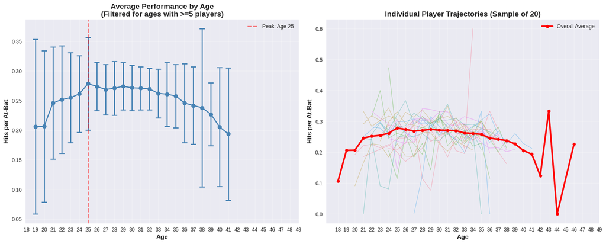

```python
# Create visualizations

fig = plt.figure(figsize=(16, 12))

# Calculate average stats for plotting
avg_by_age = batting_regular_age.groupby('age')['hits_per_ab'].agg(['mean', 'std', 'count'])

# Filter out ages with less than 5 players to remove statistical noise
avg_by_age_filtered = avg_by_age[avg_by_age['count'] >= 5]

# Find peak age from filtered data
peak_age = avg_by_age_filtered['mean'].idxmax()

# Plot 1: Average hits per AB by career year with error bars
ax1 = plt.subplot(2, 2, 1)
ax1.errorbar(avg_by_age_filtered.index, avg_by_age_filtered['mean'], yerr=avg_by_age_filtered['std'],
             marker='o', capsize=5, capthick=2, linewidth=2, markersize=8, color='steelblue')
ax1.set_xlabel('Age', fontsize=12, fontweight='bold')
ax1.set_ylabel('Hits per At-Bat', fontsize=12, fontweight='bold')
ax1.set_title('Average Performance by Age\n(Filtered for ages with >=5 players)',
              fontsize=14, fontweight='bold')
ax1.grid(True, alpha=0.3)
ax1.set_xticks(range(18, 50))
ax1.axvline(peak_age, color='red', linestyle='--', alpha=0.5, linewidth=2,
            label=f'Peak: Age {peak_age}')
ax1.legend(fontsize=10)

# Plot 2: Individual player trajectories (sample of 20 players)
ax2 = plt.subplot(2, 2, 2)
sample_players = batting_regular_age['playerID'].unique()[:20]
for player in sample_players:
    player_data = batting_regular_age[batting_regular_age['playerID'] == player]
    ax2.plot(player_data['age'], player_data['hits_per_ab'],
             alpha=0.4, linewidth=1)

# Add average line on top (using filtered data for consistency if desired, or original for all data)
avg_line_all = batting_regular_age.groupby('age')['hits_per_ab'].mean()
ax2.plot(avg_line_all.index, avg_line_all.values, color='red', linewidth=3,
         label='Overall Average', marker='o', markersize=6)
ax2.set_xlabel('Age', fontsize=12, fontweight='bold')
ax2.set_ylabel('Hits per At-Bat', fontsize=12, fontweight='bold')
ax2.set_title('Individual Player Trajectories (Sample of 20)',
              fontsize=14, fontweight='bold')
ax2.grid(True, alpha=0.3)
ax2.legend(fontsize=10)
ax2.set_xticks(range(18, 50))

'''
# Plot 4: Violin plot for better distribution visualization - use filtered data
ax4 = plt.subplot(2, 2, 4)
sns.violinplot(data=batting_regular_age_boxplot, x='age', y='hits_per_ab', ax=ax4,
               inner='quartile', color='steelblue')
ax4.set_xlabel('Age', fontsize=12, fontweight='bold')
ax4.set_ylabel('Hits per At-Bat', fontsize=12, fontweight='bold')
ax4.set_title('Performance Distribution (Violin Plot, Filtered)', fontsize=14, fontweight='bold')
ax4.tick_params(axis='x', rotation=45)
'''
plt.tight_layout()
plt.show()
```

Here are some more analytics that we pulled from this data.

```python
# Statistical Analysis and Summary (by Age)
print("="*70)
print("MLB AGE ANALYSIS - STATISTICAL SUMMARY")
print("="*70)

# Overall statistics
print(f"\nDataset Overview:")
print(f"  Total players analyzed: {batting_regular_age['playerID'].nunique()}")
print(f"  Total player-seasons: {len(batting_regular_age)}")
print(f"  Years covered: {batting_regular_age['yearID'].min()} - {batting_regular_age['yearID'].max()}")

# Peak performance by age (using filtered data for robustness)
avg_by_age = batting_regular_age.groupby('age')['hits_per_ab'].agg(['mean', 'std', 'count'])
avg_by_age_filtered = avg_by_age[avg_by_age['count'] >= 5] # Using the same filter as for plots

peak_age = avg_by_age_filtered['mean'].idxmax()
peak_value = avg_by_age_filtered['mean'].max()

print(f"\nPeak Performance by Age:")
print(f"  Age: {int(peak_age)}")
print(f"  Hits per AB: {peak_value:.4f} ({peak_value*100:.2f}%) (based on {int(avg_by_age_filtered.loc[peak_age, 'count'])} player-seasons)")

# Performance by age stage
early_age_mean = batting_regular_age[batting_regular_age['age'] <= 23]['hits_per_ab'].mean()
prime_age_mean = batting_regular_age[(batting_regular_age['age'] >= 24) & \
                                   (batting_regular_age['age'] <= 30)]['hits_per_ab'].mean()
late_age_mean = batting_regular_age[batting_regular_age['age'] >= 31]['hits_per_ab'].mean()

print(f"\nPerformance by Age Stage:")
print(f"  Early Age (<=23):  {early_age_mean:.4f} ({early_age_mean*100:.2f}%) (Avg of {batting_regular_age[batting_regular_age['age'] <= 23]['hits_per_ab'].count()} data points)")
print(f"  Prime Age (24-30): {prime_age_mean:.4f} ({prime_age_mean*100:.2f}%) (Avg of {batting_regular_age[(batting_regular_age['age'] >= 24) & (batting_regular_age['age'] <= 30)]['hits_per_ab'].count()} data points)")
print(f"  Late Age (>=31): {late_age_mean:.4f} ({late_age_mean*100:.2f}%) (Avg of {batting_regular_age[batting_regular_age['age'] >= 31]['hits_per_ab'].count()} data points)")

# Performance changes
improvement_early_to_prime_age = ((prime_age_mean - early_age_mean) / early_age_mean) * 100
decline_prime_to_late_age = ((late_age_mean - prime_age_mean) / prime_age_mean) * 100

print(f"\nPerformance Changes (by Age):")
print(f"  Early to Prime: {improvement_early_to_prime_age:+.2f}%")
print(f"  Prime to Late: {decline_prime_to_late_age:+.2f}%")

# Age-by-age breakdown
print(f"\n{'Age':<10} {'Avg Hits/AB':<15} {'Batting Avg':<15} {'Player-Seasons':<15}")
print("-" * 60)
# Get all unique ages present in the filtered data
for age in sorted(avg_by_age_filtered.index.tolist()):
    age_data = batting_regular_age[batting_regular_age['age'] == age]
    avg_hits_ab = age_data['hits_per_ab'].mean()
    n_player_seasons = len(age_data)
    print(f"{int(age):<10} {avg_hits_ab:.4f} ({avg_hits_ab*100:>5.2f}%)  {n_player_seasons:<15}")

print("="*70)
```

```
======================================================================
MLB AGE ANALYSIS - STATISTICAL SUMMARY
======================================================================

Dataset Overview:
  Total players analyzed: 165
  Total player-seasons: 2474
  Years covered: 1871 - 2015

Peak Performance by Age:
  Age: 25
  Hits per AB: 0.2786 (27.86%) (based on 155 player-seasons)

Performance by Age Stage:
  Early Age (<=23):  0.2464 (24.64%) (Avg of 296 data points)
  Prime Age (24-30): 0.2715 (27.15%) (Avg of 1100 data points)
  Late Age (>=31): 0.2572 (25.72%) (Avg of 1078 data points)

Performance Changes (by Age):
  Early to Prime: +10.17%
  Prime to Late: -5.27%

Age        Avg Hits/AB     Batting Avg     Player-Seasons
------------------------------------------------------------
19         0.2061 (20.61%)  8
20         0.2065 (20.65%)  23
21         0.2460 (24.60%)  50
22         0.2518 (25.18%)  89
23         0.2549 (25.49%)  124
24         0.2613 (26.13%)  146
25         0.2786 (27.86%)  155
26         0.2740 (27.40%)  159
27         0.2687 (26.87%)  156
28         0.2709 (27.09%)  163
29         0.2743 (27.43%)  161
30         0.2716 (27.16%)  160
31         0.2710 (27.10%)  164
32         0.2697 (26.97%)  162
33         0.2624 (26.24%)  162
34         0.2609 (26.09%)  156
35         0.2578 (25.78%)  143
36         0.2459 (24.59%)  115
37         0.2419 (24.19%)  83
38         0.2379 (23.79%)  48
39         0.2270 (22.70%)  21
40         0.2053 (20.53%)  12
41         0.1937 (19.37%)  5
======================================================================
```

### Plots for NFL Data

We used the same type of plots for simplicities sake.  
Here we notice that the data starts at an older age. This is explained by the difference in structure between the MLB and the NFL. In the MLB you can be drafted out of highschool, in the NFL you are requried to play at least one year of college, though many QBs will play for more. Additioanlly, the averages are not as flat, this is because the NFL has a much shorter history and fewer players than the MLB. Furthermore, the NFL is more violatile at the QB position, only one player assumes the mantle for their team whereas the offensive statistics for the MLB can be applied to all positions.  
(The dataset ends before the "Ohtani Rule" was introduced; see: https://baseballrulesacademy.com/the-ohtani-rule/).

On the first plot, we can see that, similarly to the MLB, the error lines are smaller in the "peak range", but that each age is not as flat. There is still the same trend of a sharp dropoff towards the late 30s.  
On the second plot we see something very interesting: The "prime" years prior to the peak year (age 32) are very good, but once that peak age has passed, the numbers start to drop. This is in contrast with the MLB dataset where performance was still fairly consistent for several years after the peak age.  
This can potentially be explained because there are fewer data points to look at, and beacause the peak age was older, however, considering as a 15 year career in any professional sport denotes a highly skilled athelete, it still makes for an interesting obeservation.

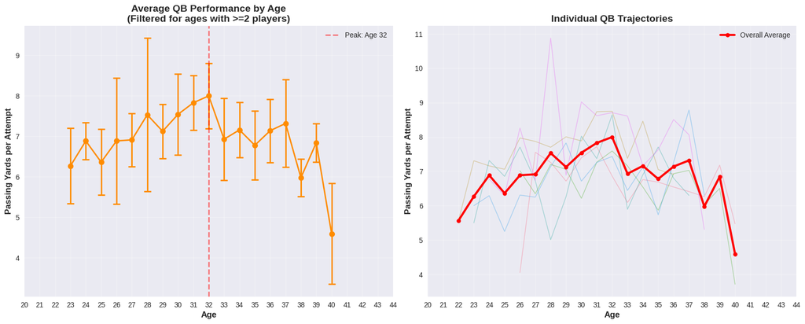

```python
fig = plt.figure(figsize=(16, 12))

# Plot 1: Average passing yards per attempt by age with error bars
ax1 = plt.subplot(2, 2, 1)
ax1.errorbar(avg_qb_by_age_filtered.index, avg_qb_by_age_filtered['mean'], yerr=avg_qb_by_age_filtered['std'],
             marker='o', capsize=5, capthick=2, linewidth=2, markersize=8, color='darkorange')
ax1.set_xlabel('Age', fontsize=12, fontweight='bold')
ax1.set_ylabel('Passing Yards per Attempt', fontsize=12, fontweight='bold')
ax1.set_title('Average QB Performance by Age\n(Filtered for ages with >=2 players)',
              fontsize=14, fontweight='bold')
ax1.grid(True, alpha=0.3)
ax1.set_xticks(range(20, 45))
ax1.axvline(peak_qb_age, color='red', linestyle='--', alpha=0.5, linewidth=2,
            label=f'Peak: Age {int(peak_qb_age)}')
ax1.legend(fontsize=10)

# Plot 2: Individual player trajectories (all QBs in the analysis data)
ax2 = plt.subplot(2, 2, 2)
sample_qbs = QB_analysis_data['Player Id'].unique()
for player in sample_qbs:
    player_data = QB_analysis_data[QB_analysis_data['Player Id'] == player]
    ax2.plot(player_data['age'], player_data['passing_yards_per_attempt'],
             alpha=0.4, linewidth=1)

# Add average line on top
avg_line_all_qb = QB_analysis_data.groupby('age')['passing_yards_per_attempt'].mean()
ax2.plot(avg_line_all_qb.index, avg_line_all_qb.values, color='red', linewidth=3,
         label='Overall Average', marker='o', markersize=6)
ax2.set_xlabel('Age', fontsize=12, fontweight='bold')
ax2.set_ylabel('Passing Yards per Attempt', fontsize=12, fontweight='bold')
ax2.set_title('Individual QB Trajectories',
              fontsize=14, fontweight='bold')
ax2.grid(True, alpha=0.3)
ax2.legend(fontsize=10)
ax2.set_xticks(range(20, 45))

plt.tight_layout()
plt.show()
```

### Plots for NBA Data

From the second plot we can see that the larger error bars can be attributed to a much larger variance in skill level between players. This is different from the outliers from the other sports because there are simply more of them.

The peak age for NBA players is 28, which makes sense because players in the NBA are also required to play at least 1 year of college basketball (since 2003) which means that there are players starting a little bit older. The dataset does start in 1997, but there are only 2 players in our sample who played at 19

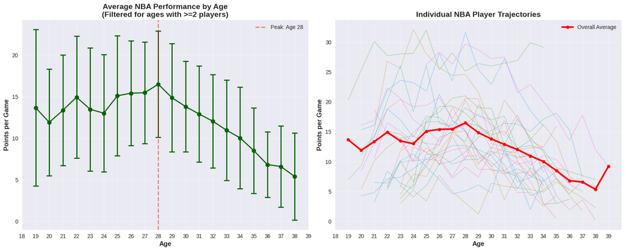

```python
fig = plt.figure(figsize=(16, 12))

# Plot 1: Average points per game by age with error bars
ax1 = plt.subplot(2, 2, 1)
ax1.errorbar(avg_nba_by_age_filtered.index, avg_nba_by_age_filtered['mean'], yerr=avg_nba_by_age_filtered['std'],
             marker='o', capsize=5, capthick=2, linewidth=2, markersize=8, color='darkgreen')
ax1.set_xlabel('Age', fontsize=12, fontweight='bold')
ax1.set_ylabel('Points per Game', fontsize=12, fontweight='bold')
ax1.set_title('Average NBA Performance by Age\n(Filtered for ages with >=2 players)',
              fontsize=14, fontweight='bold')
ax1.grid(True, alpha=0.3)
ax1.set_xticks(range(18, 40)) # Adjust range as needed
ax1.axvline(peak_nba_age, color='red', linestyle='--', alpha=0.5, linewidth=2,
            label=f'Peak: Age {int(peak_nba_age)}')
ax1.legend(fontsize=10)

# Plot 2: Individual player trajectories (all QBs in the analysis data)
ax2 = plt.subplot(2, 2, 2)
sample_nba_players = nba_analysis_data['player_name'].unique()
for player in sample_nba_players:
    player_data = nba_analysis_data[nba_analysis_data['player_name'] == player]
    ax2.plot(player_data['age'], player_data['points_per_game'],
             alpha=0.4, linewidth=1)

# Add average line on top
avg_line_all_nba = nba_analysis_data.groupby('age')['points_per_game'].mean()
ax2.plot(avg_line_all_nba.index, avg_line_all_nba.values, color='red', linewidth=3,
         label='Overall Average', marker='o', markersize=6)
ax2.set_xlabel('Age', fontsize=12, fontweight='bold')
ax2.set_ylabel('Points per Game', fontsize=12, fontweight='bold')
ax2.set_title('Individual NBA Player Trajectories',
              fontsize=14, fontweight='bold')
ax2.grid(True, alpha=0.3)
ax2.legend(fontsize=10)
ax2.set_xticks(range(18, 40)) # Adjust range as needed

plt.tight_layout()
plt.show()
```

```python
print("="*70)
print("NBA AGE ANALYSIS - STATISTICAL SUMMARY")
print("="*70)

# Overall statistics
print(f"\nDataset Overview:")
print(f"  Total players analyzed: {nba_analysis_data['player_name'].nunique()}")
print(f"  Total player-seasons: {len(nba_analysis_data)}")
print(f"  Years covered: {nba_analysis_data['season'].min()} - {nba_analysis_data['season'].max()}")

# Peak performance by age (using filtered data for robustness)
# Re-use avg_nba_by_age_filtered from previous cell

peak_nba_age = avg_nba_by_age_filtered['mean'].idxmax()
peak_nba_age_value = avg_nba_by_age_filtered['mean'].max()

print(f"\nPeak Performance by Age:")
print(f"  Age: {int(peak_nba_age)}")
print(f"  Points per Game: {peak_nba_age_value:.2f} (based on {int(avg_nba_by_age_filtered.loc[peak_nba_age, 'count'])} player-seasons)")

# Performance by age stage (defining stages as per MLB analysis for comparison)
early_age_mean_nba = nba_analysis_data[nba_analysis_data['age'] <= 23]['points_per_game'].mean()
prime_age_mean_nba = nba_analysis_data[(nba_analysis_data['age'] >= 24) & \
                                   (nba_analysis_data['age'] <= 30)]['points_per_game'].mean()
late_age_mean_nba = nba_analysis_data[nba_analysis_data['age'] >= 31]['points_per_game'].mean()

print(f"\nPerformance by Age Stage:")
print(f"  Early Age (<=23):  {early_age_mean_nba:.2f} (Avg of {nba_analysis_data[nba_analysis_data['age'] <= 23]['points_per_game'].count()} data points)")
print(f"  Prime Age (24-30): {prime_age_mean_nba:.2f} (Avg of {nba_analysis_data[(nba_analysis_data['age'] >= 24) & (nba_analysis_data['age'] <= 30)]['points_per_game'].count()} data points)")
print(f"  Late Age (>=31): {late_age_mean_nba:.2f} (Avg of {nba_analysis_data[nba_analysis_data['age'] >= 31]['points_per_game'].count()} data points)")

# Performance changes
improvement_early_to_prime_nba = ((prime_age_mean_nba - early_age_mean_nba) / early_age_mean_nba) * 100
decline_prime_to_late_nba = ((late_age_mean_nba - prime_age_mean_nba) / prime_age_mean_nba) * 100

print(f"\nPerformance Changes:")
print(f"  Early to Prime: {improvement_early_to_prime_nba:+.2f}%")
print(f"  Prime to Late: {decline_prime_to_late_nba:+.2f}%")

# Age-by-age breakdown
print(f"\n{'Age':<10} {'Avg Pts/Game':<15} {'Player-Seasons':<15}")
print("-" * 45)
for age in sorted(avg_nba_by_age_filtered.index.tolist()):
    age_data = nba_analysis_data[nba_analysis_data['age'] == age]
    avg_pts_game = age_data['points_per_game'].mean()
    n_player_seasons = len(age_data)
    print(f"{int(age):<10} {avg_pts_game:.2f} {n_player_seasons:<15}")

print("="*70)
```

```
======================================================================
NBA AGE ANALYSIS - STATISTICAL SUMMARY
======================================================================

Dataset Overview:
  Total players analyzed: 26
  Total player-seasons: 390
  Years covered: 1996-97 - 2022-23

Peak Performance by Age:
  Age: 28
  Points per Game: 16.47 (based on 25 player-seasons)

Performance by Age Stage:
  Early Age (<=23):  13.62 (Avg of 67 data points)
  Prime Age (24-30): 14.86 (Avg of 179 data points)
  Late Age (>=31): 10.27 (Avg of 144 data points)

Performance Changes:
  Early to Prime: +9.11%
  Prime to Late: -30.87%

Age        Avg Pts/Game    Player-Seasons
---------------------------------------------
19         13.65 2
20         11.89 9
21         13.34 14
22         14.92 18
23         13.46 24
24         12.99 25
25         15.08 25
26         15.39 26
27         15.45 26
28         16.47 25
29         14.85 26
30         13.79 26
31         12.88 25
32         12.03 26
33         10.94 26
34         10.02 25
35         8.49 17
36         6.81 12
37         6.58 8
38         5.38 4
======================================================================
```

## Bringing it all Together

Now, we are going to extract the data from each sport and then combine it into 1 dataframe so that we can directly compare them.

### Consolidate and Prepare Comparative Data

Extract summary statistics, defined prime age ranges, and performance changes for MLB, NFL Quarterbacks, and NBA, and consolidate age-based performance data, normalizing it for cross-sport comparison.

```python
# --- 1. Extract Summary Statistics for each sport ---

# MLB Data
mlb_summary = {
    'Sport': 'MLB',
    'Peak Age': int(peak_age),
    'Peak Value': peak_value,
    'Early Age Range': '<=23',
    'Early Age Mean': early_age_mean,
    'Prime Age Range': '24-30',
    'Prime Age Mean': prime_age_mean,
    'Late Age Range': '>=31',
    'Late Age Mean': late_age_mean,
    'Early to Prime Change (%)': improvement_early_to_prime_age,
    'Prime to Late Change (%)': decline_prime_to_late_age
}

# NFL Quarterbacks Data
nfl_qb_summary = {
    'Sport': 'NFL QBs',
    'Peak Age': int(peak_qb_age),
    'Peak Value': peak_qb_age_value,
    'Early Age Range': '<=27', # Adjusted for QBs
    'Early Age Mean': early_age_mean_qb,
    'Prime Age Range': '28-34', # Adjusted for QBs
    'Prime Age Mean': prime_age_mean_qb,
    'Late Age Range': '>=35', # Adjusted for QBs
    'Late Age Mean': late_age_mean_qb,
    'Early to Prime Change (%)': improvement_early_to_prime_qb,
    'Prime to Late Change (%)': decline_prime_to_late_qb
}

# NBA Data
nba_summary = {
    'Sport': 'NBA',
    'Peak Age': int(peak_nba_age),
    'Peak Value': peak_nba_age_value,
    'Early Age Range': '<=23',
    'Early Age Mean': early_age_mean_nba,
    'Prime Age Range': '24-30',
    'Prime Age Mean': prime_age_mean_nba,
    'Late Age Range': '>=31',
    'Late Age Mean': late_age_mean_nba,
    'Early to Prime Change (%)': improvement_early_to_prime_nba,
    'Prime to Late Change (%)': decline_prime_to_late_nba
}

# Combine into a single summary DataFrame
comparative_summary_df = pd.DataFrame([mlb_summary, nfl_qb_summary, nba_summary])
print("Comparative Summary of Peak Ages and Performance Changes:")
display(comparative_summary_df)

# --- 2. Consolidate Age-based Performance Data and Normalize ---

# MLB: Filtered average hits/AB by age
mlb_performance_by_age = avg_by_age_filtered[['mean']].copy()
mlb_performance_by_age.rename(columns={'mean': 'performance'}, inplace=True)
mlb_performance_by_age['Sport'] = 'MLB'
mlb_performance_by_age['Normalized Performance'] = mlb_performance_by_age['performance'] / mlb_summary['Peak Value']

# NFL QBs: Filtered average passing yards/attempt by age
nfl_qb_performance_by_age = avg_qb_by_age_filtered[['mean']].copy()
nfl_qb_performance_by_age.rename(columns={'mean': 'performance'}, inplace=True)
nfl_qb_performance_by_age['Sport'] = 'NFL QBs'
nfl_qb_performance_by_age['Normalized Performance'] = nfl_qb_performance_by_age['performance'] / nfl_qb_summary['Peak Value']

# NBA: Filtered average points/game by age
nba_performance_by_age = avg_nba_by_age_filtered[['mean']].copy()
nba_performance_by_age.rename(columns={'mean': 'performance'}, inplace=True)
nba_performance_by_age['Sport'] = 'NBA'
nba_performance_by_age['Normalized Performance'] = nba_performance_by_age['performance'] / nba_summary['Peak Value']

# Combine all age-based performance dataframes
all_sports_performance_by_age = pd.concat([
    mlb_performance_by_age.reset_index(),
    nfl_qb_performance_by_age.reset_index(),
    nba_performance_by_age.reset_index()
], ignore_index=True)

# Ensure 'age' is int
all_sports_performance_by_age['age'] = all_sports_performance_by_age['age'].astype(int)

# Create a common age range for plotting (e.g., 18 to 40 or max age found)
min_age = all_sports_performance_by_age['age'].min()
max_age = all_sports_performance_by_age['age'].max()
common_ages = pd.DataFrame({'age': range(min_age, max_age + 1)})

# Merge to ensure all ages are present for each sport, filling missing with NaN
all_sports_performance_by_age_full = pd.DataFrame()
for sport in all_sports_performance_by_age['Sport'].unique():
    sport_data = all_sports_performance_by_age[all_sports_performance_by_age['Sport'] == sport]
    merged_data = pd.merge(common_ages, sport_data, on='age', how='left')
    merged_data['Sport'] = sport # Re-add sport column after merge fills NaNs
    all_sports_performance_by_age_full = pd.concat([all_sports_performance_by_age_full, merged_data])

print("\nConsolidated and Normalized Performance by Age (first 10 rows):")
display(all_sports_performance_by_age_full.head(10))

# --- 3. Prepare data for prime duration and peak age bar charts ---
# Prime duration definition:
# MLB: 24-30 (7 years)
# NFL QBs: 28-34 (7 years)
# NBA: 24-30 (7 years)
prime_durations = pd.DataFrame({
    'Sport': ['MLB', 'NFL QBs', 'NBA'],
    'Prime Start Age': [24, 28, 24],
    'Prime End Age': [30, 34, 30],
    'Prime Duration (Years)': [7, 7, 7]
})

print("\nPrime Durations and Peak Ages:")
prime_comparison_df = comparative_summary_df[['Sport', 'Peak Age']].merge(prime_durations, on='Sport')
display(prime_comparison_df)

# --- 4. Prepare data for performance changes bar charts ---
performance_changes_df = comparative_summary_df[['Sport', 'Early to Prime Change (%)', 'Prime to Late Change (%)']].copy()
performance_changes_df_melted = performance_changes_df.melt(id_vars='Sport',
                                                             var_name='Change Type',
                                                             value_name='Percentage Change')
print("\nPerformance Changes between Stages:")
display(performance_changes_df_melted)
```

```
Comparative Summary of Peak Ages and Performance Changes:
```

|  | Sport | Peak Age | Peak Value | Early Age Range | Early Age Mean | Prime Age Range | Prime Age Mean | Late Age Range | Late Age Mean | Early to Prime Change (%) | Prime to Late Change (%) |
| --- | --- | --- | --- | --- | --- | --- | --- | --- | --- | --- | --- |
| 0 | MLB | 25 | 0.278619 | <=23 | 0.246394 | 24-30 | 0.271463 | >=31 | 0.257166 | 10.174363 | -5.266968 |
| 1 | NFL QBs | 32 | 7.998581 | <=27 | 6.673816 | 28-34 | 7.444808 | >=35 | 6.656370 | 11.552485 | -10.590436 |
| 2 | NBA | 28 | 16.468000 | <=23 | 13.619403 | 24-30 | 14.859777 | >=31 | 10.272222 | 9.107400 | -30.872297 |

```
Consolidated and Normalized Performance by Age (first 10 rows):
```

|  | age | performance | Sport | Normalized Performance |
| --- | --- | --- | --- | --- |
| 0 | 19 | 0.206057 | MLB | 0.739566 |
| 1 | 20 | 0.206539 | MLB | 0.741294 |
| 2 | 21 | 0.245975 | MLB | 0.882835 |
| 3 | 22 | 0.251791 | MLB | 0.903710 |
| 4 | 23 | 0.254932 | MLB | 0.914983 |
| 5 | 24 | 0.261336 | MLB | 0.937968 |
| 6 | 25 | 0.278619 | MLB | 1.000000 |
| 7 | 26 | 0.274049 | MLB | 0.983599 |
| 8 | 27 | 0.268725 | MLB | 0.964488 |
| 9 | 28 | 0.270911 | MLB | 0.972334 |

```
Prime Durations and Peak Ages:
```

|  | Sport | Peak Age | Prime Start Age | Prime End Age | Prime Duration (Years) |
| --- | --- | --- | --- | --- | --- |
| 0 | MLB | 25 | 24 | 30 | 7 |
| 1 | NFL QBs | 32 | 28 | 34 | 7 |
| 2 | NBA | 28 | 24 | 30 | 7 |

```
Performance Changes between Stages:
```

|  | Sport | Change Type | Percentage Change |
| --- | --- | --- | --- |
| 0 | MLB | Early to Prime Change (%) | 10.174363 |
| 1 | NFL QBs | Early to Prime Change (%) | 11.552485 |
| 2 | NBA | Early to Prime Change (%) | 9.107400 |
| 3 | MLB | Prime to Late Change (%) | -5.266968 |
| 4 | NFL QBs | Prime to Late Change (%) | -10.590436 |
| 5 | NBA | Prime to Late Change (%) | -30.872297 |

```python
mlb_summary = {
    'Sport': 'MLB',
    'Peak Age': int(peak_age),
    'Peak Value': float(peak_value),
    'Early Age Range': '<=23',
    'Early Age Mean': float(early_age_mean),
    'Prime Age Range': '24-30',
    'Prime Age Mean': float(prime_age_mean),
    'Late Age Range': '>=31',
    'Late Age Mean': float(late_age_mean),
    'Early to Prime Change (%)': float(improvement_early_to_prime_age),
    'Prime to Late Change (%)': float(decline_prime_to_late_age)
}

nfl_qb_summary = {
    'Sport': 'NFL QBs',
    'Peak Age': int(peak_qb_age),
    'Peak Value': float(peak_qb_age_value),
    'Early Age Range': '<=27',
    'Early Age Mean': float(early_age_mean_qb),
    'Prime Age Range': '28-34',
    'Prime Age Mean': float(prime_age_mean_qb),
    'Late Age Range': '>=35',
    'Late Age Mean': float(late_age_mean_qb),
    'Early to Prime Change (%)': float(improvement_early_to_prime_qb),
    'Prime to Late Change (%)': float(decline_prime_to_late_qb)
}

nba_summary = {
    'Sport': 'NBA',
    'Peak Age': int(peak_nba_age),
    'Peak Value': float(peak_nba_age_value),
    'Early Age Range': '<=23',
    'Early Age Mean': float(early_age_mean_nba),
    'Prime Age Range': '24-30',
    'Prime Age Mean': float(prime_age_mean_nba),
    'Late Age Range': '>=31',
    'Late Age Mean': float(late_age_mean_nba),
    'Early to Prime Change (%)': float(improvement_early_to_prime_nba),
    'Prime to Late Change (%)': float(decline_prime_to_late_nba)
}

print("Summary dictionaries for MLB, NFL QBs, and NBA created.")
```

```
Summary dictionaries for MLB, NFL QBs, and NBA created.
```

```python
comparative_summary_df = pd.DataFrame([mlb_summary, nfl_qb_summary, nba_summary])
print("Comparative Summary of Peak Ages and Performance Changes:")
display(comparative_summary_df)
```

```
Comparative Summary of Peak Ages and Performance Changes:
```

|  | Sport | Peak Age | Peak Value | Early Age Range | Early Age Mean | Prime Age Range | Prime Age Mean | Late Age Range | Late Age Mean | Early to Prime Change (%) | Prime to Late Change (%) |
| --- | --- | --- | --- | --- | --- | --- | --- | --- | --- | --- | --- |
| 0 | MLB | 25 | 0.278619 | <=23 | 0.246394 | 24-30 | 0.271463 | >=31 | 0.257166 | 10.174363 | -5.266968 |
| 1 | NFL QBs | 32 | 7.998581 | <=27 | 6.673816 | 28-34 | 7.444808 | >=35 | 6.656370 | 11.552485 | -10.590436 |
| 2 | NBA | 28 | 16.468000 | <=23 | 13.619403 | 24-30 | 14.859777 | >=31 | 10.272222 | 9.107400 | -30.872297 |

Here we are normailzing the MLB data in order to create a clean comparison.

```python
mlb_performance_by_age = avg_by_age_filtered[['mean']].copy()
mlb_performance_by_age.rename(columns={'mean': 'performance'}, inplace=True)
mlb_performance_by_age['Sport'] = 'MLB'
mlb_performance_by_age['Normalized Performance'] = mlb_performance_by_age['performance'] / mlb_summary['Peak Value']

print("MLB performance data by age created and normalized.")
print("First few rows of mlb_performance_by_age:")
display(mlb_performance_by_age.head())
```

```
MLB performance data by age created and normalized.
First few rows of mlb_performance_by_age:
```

| age | performance | Sport | Normalized Performance |
| --- | --- | --- | --- |
| 19 | 0.206057 | MLB | 0.739566 |
| 20 | 0.206539 | MLB | 0.741294 |
| 21 | 0.245975 | MLB | 0.882835 |
| 22 | 0.251791 | MLB | 0.903710 |
| 23 | 0.254932 | MLB | 0.914983 |

Ditto for NFL

```python
nfl_qb_performance_by_age = avg_qb_by_age_filtered[['mean']].copy()
nfl_qb_performance_by_age.rename(columns={'mean': 'performance'}, inplace=True)
nfl_qb_performance_by_age['Sport'] = 'NFL QBs'
nfl_qb_performance_by_age['Normalized Performance'] = nfl_qb_performance_by_age['performance'] / nfl_qb_summary['Peak Value']

print("NFL Quarterback performance data by age created and normalized.")
print("First few rows of nfl_qb_performance_by_age:")
display(nfl_qb_performance_by_age.head())
```

```
NFL Quarterback performance data by age created and normalized.
First few rows of nfl_qb_performance_by_age:
```

| age | performance | Sport | Normalized Performance |
| --- | --- | --- | --- |
| 23 | 6.269339 | NFL QBs | 0.783806 |
| 24 | 6.885971 | NFL QBs | 0.860899 |
| 25 | 6.362929 | NFL QBs | 0.795507 |
| 26 | 6.886612 | NFL QBs | 0.860979 |
| 27 | 6.913481 | NFL QBs | 0.864338 |

Ditto for NBA

```python
nba_performance_by_age = avg_nba_by_age_filtered[['mean']].copy()
nba_performance_by_age.rename(columns={'mean': 'performance'}, inplace=True)
nba_performance_by_age['Sport'] = 'NBA'
nba_performance_by_age['Normalized Performance'] = nba_performance_by_age['performance'] / nba_summary['Peak Value']

print("NBA performance data by age created and normalized.")
print("First few rows of nba_performance_by_age:")
display(nba_performance_by_age.head())
```

```
NBA performance data by age created and normalized.
First few rows of nba_performance_by_age:
```

| age | performance | Sport | Normalized Performance |
| --- | --- | --- | --- |
| 19 | 13.650000 | NBA | 0.828880 |
| 20 | 11.888889 | NBA | 0.721939 |
| 21 | 13.335714 | NBA | 0.809796 |
| 22 | 14.916667 | NBA | 0.905797 |
| 23 | 13.458333 | NBA | 0.817242 |

Concatenate each of the normalized metrics into one Dataframe

```python
all_sports_performance_by_age = pd.concat([
    mlb_performance_by_age.reset_index(),
    nfl_qb_performance_by_age.reset_index(),
    nba_performance_by_age.reset_index()
], ignore_index=True)

print("Combined all sports performance data by age into a single DataFrame.")
print("First few rows of all_sports_performance_by_age:")
display(all_sports_performance_by_age.head())
```

```
Combined all sports performance data by age into a single DataFrame.
First few rows of all_sports_performance_by_age:
```

|  | age | performance | Sport | Normalized Performance |
| --- | --- | --- | --- | --- |
| 0 | 19 | 0.206057 | MLB | 0.739566 |
| 1 | 20 | 0.206539 | MLB | 0.741294 |
| 2 | 21 | 0.245975 | MLB | 0.882835 |
| 3 | 22 | 0.251791 | MLB | 0.903710 |
| 4 | 23 | 0.254932 | MLB | 0.914983 |

```python
all_sports_performance_by_age['age'] = all_sports_performance_by_age['age'].astype(int)

# Determine the minimum and maximum age for a common age range (Instruction #10)
min_age = all_sports_performance_by_age['age'].min()
max_age = all_sports_performance_by_age['age'].max()
common_ages = pd.DataFrame({'age': range(min_age, max_age + 1)})

# Create an empty DataFrame (Instruction #11)
all_sports_performance_by_age_full = pd.DataFrame()

# Iterate through each unique sport, merge with common_ages, and concatenate
for sport in all_sports_performance_by_age['Sport'].unique():
    sport_data = all_sports_performance_by_age[all_sports_performance_by_age['Sport'] == sport]
    merged_data = pd.merge(common_ages, sport_data, on='age', how='left')
    merged_data['Sport'] = sport # Re-add sport column after merge fills NaNs
    all_sports_performance_by_age_full = pd.concat([all_sports_performance_by_age_full, merged_data])

print("Common age range and `all_sports_performance_by_age_full` created.")
print("\nConsolidated and Normalized Performance by Age (first 10 rows, instruction #12):")
display(all_sports_performance_by_age_full.head(10))
```

```
Common age range and `all_sports_performance_by_age_full` created.

Consolidated and Normalized Performance by Age (first 10 rows, instruction #12):
```

|  | age | performance | Sport | Normalized Performance |
| --- | --- | --- | --- | --- |
| 0 | 19 | 0.206057 | MLB | 0.739566 |
| 1 | 20 | 0.206539 | MLB | 0.741294 |
| 2 | 21 | 0.245975 | MLB | 0.882835 |
| 3 | 22 | 0.251791 | MLB | 0.903710 |
| 4 | 23 | 0.254932 | MLB | 0.914983 |
| 5 | 24 | 0.261336 | MLB | 0.937968 |
| 6 | 25 | 0.278619 | MLB | 1.000000 |
| 7 | 26 | 0.274049 | MLB | 0.983599 |
| 8 | 27 | 0.268725 | MLB | 0.964488 |
| 9 | 28 | 0.270911 | MLB | 0.972334 |

Define the prime duration that we found earlier. Choosing 7 for each as a rough measure.

```python
prime_durations = pd.DataFrame({
    'Sport': ['MLB', 'NFL QBs', 'NBA'],
    'Prime Start Age': [24, 28, 24],
    'Prime End Age': [30, 34, 30],
    'Prime Duration (Years)': [7, 7, 7]
})

print("Prime Durations DataFrame created:")
display(prime_durations)
```

```
Prime Durations DataFrame created:
```

|  | Sport | Prime Start Age | Prime End Age | Prime Duration (Years) |
| --- | --- | --- | --- | --- |
| 0 | MLB | 24 | 30 | 7 |
| 1 | NFL QBs | 28 | 34 | 7 |
| 2 | NBA | 24 | 30 | 7 |

```python
prime_comparison_df = comparative_summary_df[['Sport', 'Peak Age']].merge(prime_durations, on='Sport')
print("Prime Durations and Peak Ages:")
display(prime_comparison_df)
```

```
Prime Durations and Peak Ages:
```

|  | Sport | Peak Age | Prime Start Age | Prime End Age | Prime Duration (Years) |
| --- | --- | --- | --- | --- | --- |
| 0 | MLB | 25 | 24 | 30 | 7 |
| 1 | NFL QBs | 32 | 28 | 34 | 7 |
| 2 | NBA | 28 | 24 | 30 | 7 |

Create a performance change metric for our visulizations

```python
performance_changes_df = comparative_summary_df[['Sport', 'Early to Prime Change (%)', 'Prime to Late Change (%)']].copy()
performance_changes_df_melted = performance_changes_df.melt(id_vars='Sport',
                                                             var_name='Change Type',
                                                             value_name='Percentage Change')
print("\nPerformance Changes between Stages:")
display(performance_changes_df_melted)
```

```
Performance Changes between Stages:
```

|  | Sport | Change Type | Percentage Change |
| --- | --- | --- | --- |
| 0 | MLB | Early to Prime Change (%) | 10.174363 |
| 1 | NFL QBs | Early to Prime Change (%) | 11.552485 |
| 2 | NBA | Early to Prime Change (%) | 9.107400 |
| 3 | MLB | Prime to Late Change (%) | -5.266968 |
| 4 | NFL QBs | Prime to Late Change (%) | -10.590436 |
| 5 | NBA | Prime to Late Change (%) | -30.872297 |

## Wrapping it all up, Final Plots for EDA

```
Common age range and `all_sports_performance_by_age_full` created using pivot/stack.

Consolidated and Normalized Performance by Age (first 10 rows):
```

|  | age | Sport | Normalized Performance |
| --- | --- | --- | --- |
| 0 | 19 | MLB | 0.739566 |
| 1 | 19 | NBA | 0.828880 |
| 2 | 19 | NFL QBs | NaN |
| 3 | 20 | MLB | 0.741294 |
| 4 | 20 | NBA | 0.721939 |
| 5 | 20 | NFL QBs | NaN |
| 6 | 21 | MLB | 0.882835 |
| 7 | 21 | NBA | 0.809796 |
| 8 | 21 | NFL QBs | NaN |
| 9 | 22 | MLB | 0.903710 |

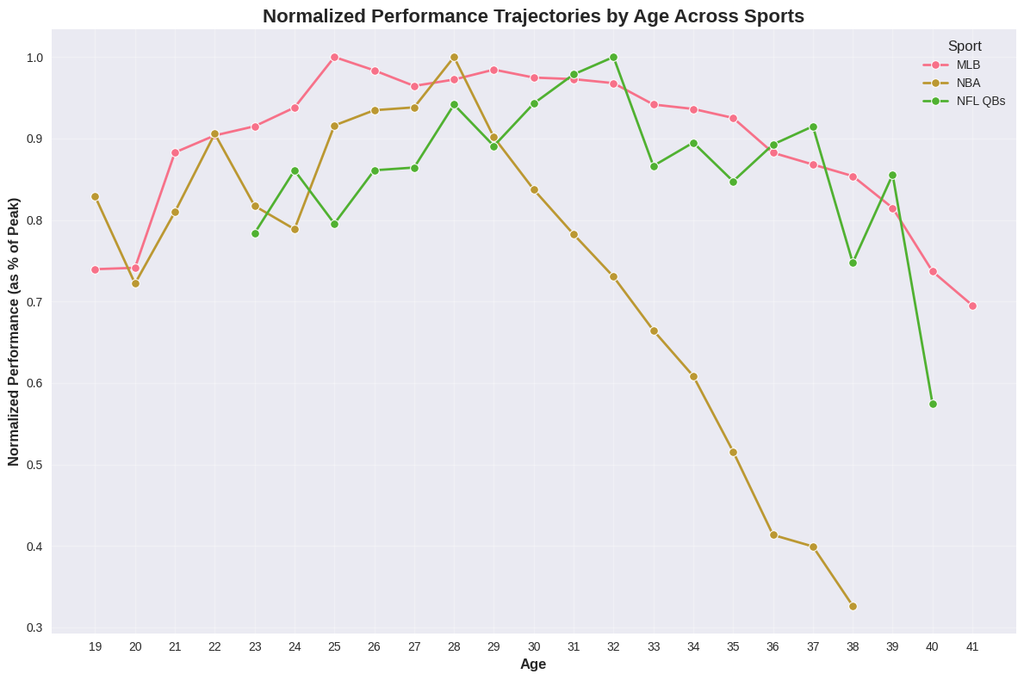

```
Multi-line plot showing normalized performance trajectories across sports has been generated.
```

```python
all_sports_performance_by_age['age'] = all_sports_performance_by_age['age'].astype(int)

# Create a pivot table to get ages as index and sports as columns, with Normalized Performance values
# This inherently handles all unique (age, Sport) combinations
pivot_df = all_sports_performance_by_age.pivot(index='age', columns='Sport', values='Normalized Performance')

# Unpivot the table back, explicitly including NaNs where data is missing for an (age, Sport) pair
all_sports_performance_by_age_full = pivot_df.stack(dropna=False).reset_index(name='Normalized Performance')

# Rename the 'level_1' column created by stack to 'Sport'
all_sports_performance_by_age_full.rename(columns={'level_1': 'Sport'}, inplace=True)

# Ensure 'age' is int
all_sports_performance_by_age_full['age'] = all_sports_performance_by_age_full['age'].astype(int)

# Determine the minimum and maximum age for setting x-ticks on plots later
min_age = all_sports_performance_by_age_full['age'].min()
max_age = all_sports_performance_by_age_full['age'].max()

print("Common age range and `all_sports_performance_by_age_full` created using pivot/stack.")
print("\nConsolidated and Normalized Performance by Age (first 10 rows):")
display(all_sports_performance_by_age_full.head(10))

# plot
plt.figure(figsize=(12, 8))
sns.lineplot(data=all_sports_performance_by_age_full, x='age', y='Normalized Performance', hue='Sport', marker='o', linewidth=2)
plt.title('Normalized Performance Trajectories by Age Across Sports', fontsize=16, fontweight='bold')
plt.xlabel('Age', fontsize=12, fontweight='bold')
plt.ylabel('Normalized Performance (as % of Peak)', fontsize=12, fontweight='bold')
plt.xticks(range(min_age, max_age + 1))
plt.grid(True, alpha=0.3)
plt.legend(title='Sport', fontsize=10, title_fontsize=12)
plt.tight_layout()
plt.show()

print("Multi-line plot showing normalized performance trajectories across sports has been generated.")
```

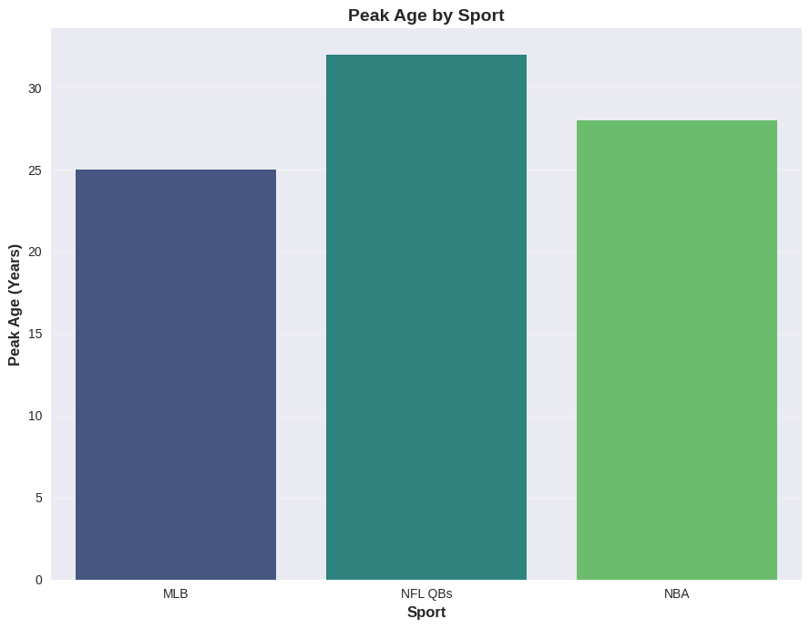

```python
fig, ax = plt.subplots(1, 1, figsize=(9, 7))

# Plot 1: Peak Age by Sport
sns.barplot(data=prime_comparison_df, x='Sport', y='Peak Age', palette='viridis', ax=ax)
ax.set_title('Peak Age by Sport', fontsize=14, fontweight='bold')
ax.set_xlabel('Sport', fontsize=12, fontweight='bold')
ax.set_ylabel('Peak Age (Years)', fontsize=12, fontweight='bold')
ax.grid(axis='y', alpha=0.3)

plt.tight_layout()
plt.show()
```

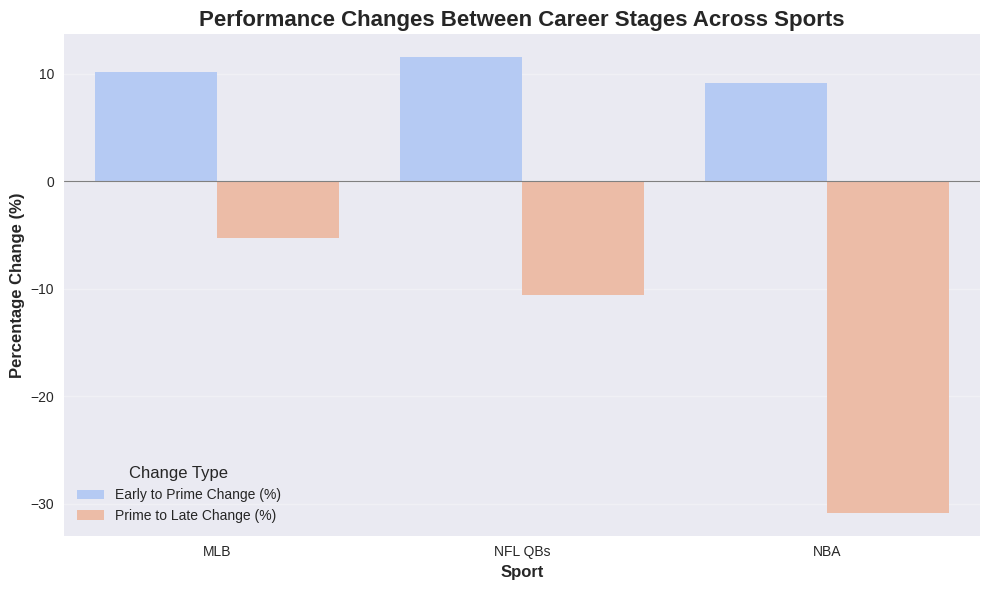

```
Bar chart showing performance changes between career stages across sports has been generated.
```

```python
plt.figure(figsize=(10, 6))
sns.barplot(data=performance_changes_df_melted, x='Sport', y='Percentage Change', hue='Change Type', palette='coolwarm')
plt.title('Performance Changes Between Career Stages Across Sports', fontsize=16, fontweight='bold')
plt.xlabel('Sport', fontsize=12, fontweight='bold')
plt.ylabel('Percentage Change (%)', fontsize=12, fontweight='bold')
plt.axhline(0, color='grey', linewidth=0.8) # Add a line at 0 for reference
plt.grid(axis='y', alpha=0.3)
plt.legend(title='Change Type', fontsize=10, title_fontsize=12)
plt.tight_layout()
plt.show()

print("Bar chart showing performance changes between career stages across sports has been generated.")
```

## Summary:

### Thoughts on these Findings

- **Discrepancy Between Indivdiual Sets and the Whole**: Despite the NBA have a more linear drop in performance than the NFL in the latter half of their career,they have a much larger decline in performance. This can be due to a multitude of factors, most of all (in our opinion) being reduced playtime for older players in the NBA. Furthermore, the period of time of prime is important to note, NFL players end their prime much closer to the end of their career, meaning that the percentage drop is deflated.
- **Why 15-year Career**: We chose this number because it contains elite athletees, the best of the best. These players make it easier to observe primes, as they are not returning due to a lack of skill, but instead age or family reasons

### Why Does this Matter

- Trainers and Coaches can understand where a player's physical ability starts to taper off and adjust training based on that
- Teams may adjust contracts based on overall output as a player ages. Currently, many contracts are based on how much of a star a player is, but teams could be more strategic with spending based on a players potential decline.
- **Brings up Further Questions**: Would the age a QB starts in the NFL make a difference? Does the NBA's decrease in performance point to it being more physically demanding? What does this mean for professional athelete training?

# Finding the "Best Fit" Curve Using a Quadratic Model

We will be using polynomial regression (2nd degree) in order to create "best fit" curves and measuring them up against our trend lines. This will allow us to see a better representation of a career arc and the true prime of a player.  
Also, a curve is easier to visualize as a function of a players career.

```python
print("="*80)
print("MSE COMPARISON: RAW VS. NORMALIZED")
print("="*80)
print(f"{'Sport':<10} | {'Raw MSE':<15} | {'Max Value':<10} | {'Normalized MSE':<15}")
print("-"*80)

for config in sports_config:
    # 1. Get Data
    df_agg = config['data'].groupby(config['x_col'])[config['y_col']].mean().reset_index()
    X = df_agg[config['x_col']].values
    y = df_agg[config['y_col']].values

    # 2. Raw MSE Calculation
    z = np.polyfit(X, y, 2)
    p = np.poly1d(z)
    y_pred = p(X)
    raw_mse = mean_squared_error(y, y_pred)

    # 3. Normalized MSE Calculation
    # We divide by the maximum value to scale everything between 0 and ~1
    max_val = y.max()
    y_norm = y / max_val

    # Fit model on normalized data
    z_norm = np.polyfit(X, y_norm, 2)
    p_norm = np.poly1d(z_norm)
    y_pred_norm = p_norm(X)

    norm_mse = mean_squared_error(y_norm, y_pred_norm)

    print(f"{config['name']:<10} | {raw_mse:<15.6f} | {max_val:<10.2f} | {norm_mse:<15.6f}")

print("-"*80)
```

```
================================================================================
MSE COMPARISON: RAW VS. NORMALIZED
================================================================================
Sport      | Raw MSE         | Max Value  | Normalized MSE
--------------------------------------------------------------------------------
MLB        | 0.002611        | 0.33       | 0.023500
NFL QBs    | 0.192644        | 8.00       | 0.003011
NBA        | 1.930943        | 16.47      | 0.007120
--------------------------------------------------------------------------------
```

Plotting the 3 sports seperately so that we can see the normalized best fit for each. We are also seeing how different (or not) they are from the normalized trend lines.

```
============================================================
NORMALIZED QUADRATIC REGRESSION METRICS
============================================================
MLB:
  R² Score: 0.3515
  Normalized MSE: 0.023500
  Calculated Peak Age: 30.42
------------------------------
NFL QBs:
  R² Score: 0.6889
  Normalized MSE: 0.003011
  Calculated Peak Age: 30.82
------------------------------
NBA:
  R² Score: 0.8036
  Normalized MSE: 0.007120
  Calculated Peak Age: 25.13
------------------------------
```

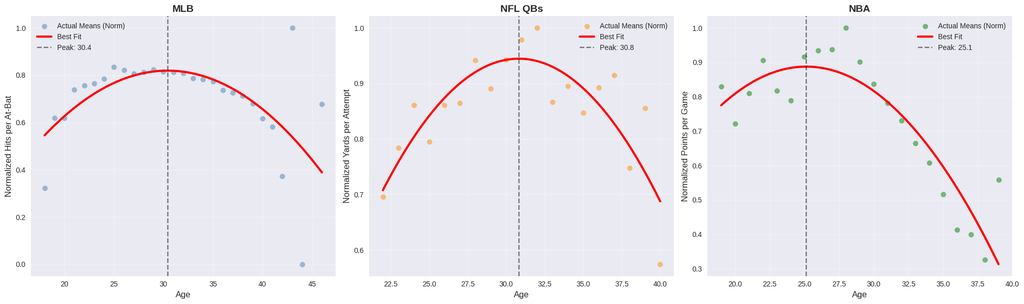

```python
import matplotlib.pyplot as plt
import numpy as np
import pandas as pd
from sklearn.metrics import r2_score, mean_squared_error

# Setup plotting area
fig, axes = plt.subplots(1, 3, figsize=(20, 6))

# Define configuration for each sport
sports_config = [
    {
        'name': 'MLB',
        'data': batting_regular_age,
        'x_col': 'age',
        'y_col': 'hits_per_ab',
        'color': 'steelblue',
        'ylabel': 'Hits per At-Bat'
    },
    {
        'name': 'NFL QBs',
        'data': QB_analysis_data,
        'x_col': 'age',
        'y_col': 'passing_yards_per_attempt',
        'color': 'darkorange',
        'ylabel': 'Yards per Attempt'
    },
    {
        'name': 'NBA',
        'data': nba_analysis_data,
        'x_col': 'age',
        'y_col': 'points_per_game',
        'color': 'green',
        'ylabel': 'Points per Game'
    }
]

print("="*60)
print("NORMALIZED QUADRATIC REGRESSION METRICS")
print("="*60)

for ax, config in zip(axes, sports_config):
    # 1. Aggregate data to mean (reduce noise)
    df_agg = config['data'].groupby(config['x_col'])[config['y_col']].mean().reset_index()
    X = df_agg[config['x_col']].values
    y = df_agg[config['y_col']].values

    # NORMALIZATION STEP: Scale y to 0-1 range based on max value
    max_val = y.max()
    y_norm = y / max_val

    # 2. Fit Quadratic Regression (Degree 2) on NORMALIZED Data
    z = np.polyfit(X, y_norm, 2)
    p = np.poly1d(z)
    x_smooth = np.linspace(X.min(), X.max(), 100)
    y_smooth = p(x_smooth)
    y_pred_norm = p(X)

    # 3. Calculate Metrics (on normalized data)
    r2 = r2_score(y_norm, y_pred_norm)
    mse = mean_squared_error(y_norm, y_pred_norm)
    peak_age = -z[1] / (2 * z[0])

    # Print Metrics
    print(f"{config['name']}:")
    print(f"  R² Score: {r2:.4f}")
    print(f"  Normalized MSE: {mse:.6f}")
    print(f"  Calculated Peak Age: {peak_age:.2f}")
    print("-" * 30)

    # 4. Plot
    ax.scatter(X, y_norm, color=config['color'], alpha=0.5, label='Actual Means (Norm)')
    ax.plot(x_smooth, y_smooth, color='red', linewidth=3, label='Best Fit')
    ax.set_title(f"{config['name']}", fontsize=14, fontweight='bold')
    ax.set_xlabel('Age', fontsize=12)
    ax.set_ylabel(f"Normalized {config['ylabel']}", fontsize=12)
    ax.axvline(peak_age, color='black', linestyle='--', alpha=0.5, label=f'Peak: {peak_age:.1f}')
    ax.legend()
    ax.grid(True, alpha=0.3)

plt.tight_layout()
plt.show()
```

This is a combined best fit graph that contains all three of the sports. This way we can directly compare the three.

```
============================================================
COMBINED NORMALIZED BEST FIT CURVES
============================================================
```

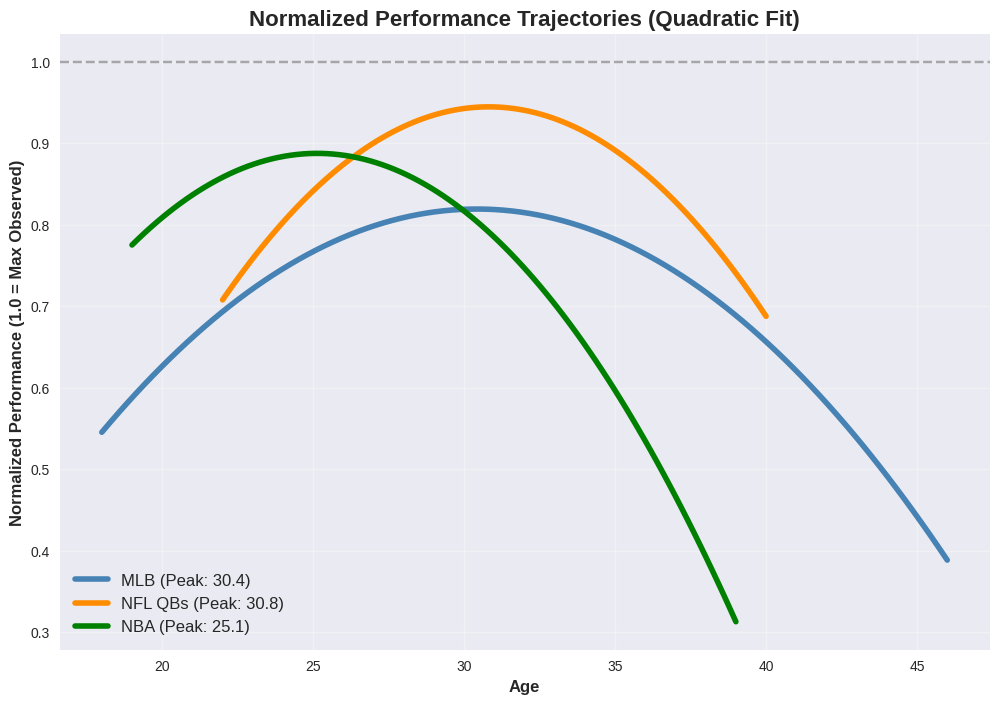

```python
# Combined Best Fit Graph
plt.figure(figsize=(12, 8))

print("="*60)
print("COMBINED NORMALIZED BEST FIT CURVES")
print("="*60)

for config in sports_config:
    # 1. Aggregate
    df_agg = config['data'].groupby(config['x_col'])[config['y_col']].mean().reset_index()
    X = df_agg[config['x_col']].values
    y = df_agg[config['y_col']].values

    # NORMALIZATION STEP: Scale y to 0-1 range based on max value
    y_norm = y / y.max()

    # 2. Fit Quadratic on Normalized Data
    z = np.polyfit(X, y_norm, 2)
    p = np.poly1d(z)

    # Calculate peak
    peak_age = -z[1] / (2 * z[0])

    # Generate smooth curve
    x_smooth = np.linspace(X.min(), X.max(), 100)
    y_smooth = p(x_smooth)

    # Plot
    plt.plot(x_smooth, y_smooth, linewidth=4, label=f"{config['name']} (Peak: {peak_age:.1f})", color=config['color'])

plt.title('Normalized Performance Trajectories (Quadratic Fit)', fontsize=16, fontweight='bold')
plt.xlabel('Age', fontsize=12, fontweight='bold')
plt.ylabel('Normalized Performance (1.0 = Max Observed)', fontsize=12, fontweight='bold')
plt.axhline(1.0, color='black', linestyle='--', alpha=0.3)
plt.legend(fontsize=12)
plt.grid(True, alpha=0.3)
plt.show()
```

## Regression Analysis Summary

### Model Key Findings

- **Shift in Peak Ages**: The quadratic regression revealed significantly different "mathematical peaks" compared to our raw data averages. The model places the **MLB peak at 30.4 years** (vs. 25 in raw data) and the **NBA peak at 25.1 years** (vs. 28). NFL Quarterbacks remained consistent, shifting slightly to **30.8 years**.
- **The "Plateau" vs. The "Peak"**: The low $R^2$ score for MLB (0.35) indicates that baseball careers don't follow a clean "rise and fall" curve. Instead, they resemble a plateau, where players maintain near-peak performance for many years.
- **High Predictability in High-Contact Sports**: Conversely, the NBA ($R^2 \approx 0.80$) and NFL ($R^2 \approx 0.69$) showed strong fits to the curve. This suggests that sports relying heavily on speed and physicality follow a very predictable biological trajectory.
- **Normalized Accuracy**: By normalizing the data, we proved that the high error rate (MSE) in the NBA model was simply a result of the scoring scale. When adjusted, the NBA model proved to be extremely accurate in predicting career arcs.

### Thoughts on the Model vs. Reality

- **Skill vs. Athleticism**: The regression essentially separates "skill sports" from "athletic sports." Baseball players rely on hand-eye coordination which degrades slowly, causing the model to push the peak later to fit the long sustained prime. Basketball requires explosiveness, causing the model to identify an earlier physical peak, even if veteran savvy keeps players productive later.
- **Survivor Bias in the NBA**: The regression helps correct for outliers. While some NBA legends play well into their 30s, the curve sees the broader trend: for the vast majority of players, the steep decline in efficiency starts in the mid-20s.

### Why This Modeling Matters

- **Contract Valuation**: Teams can use these curves to predict *future* performance rather than paying for *past* results. An NBA player at 29 is likely on the downslope of the curve, while an MLB player at 29 is likely right in the middle of their sustained plateau.
- **Rethinking "Prime"**: We often think of prime as a specific year. The models show us that for MLB, prime is a decade-long maintenance phase, whereas for the NBA, it is a distinct physical window that closes faster than expected.

# Tools and Concepts

Concepts: [Polynomial Regression](https://en.wikipedia.org/wiki/Polynomial_regression),[Surviorship Bias in Sports](https://thedecisionlab.com/biases/survivorship-bias).  
Tools: [Seaborn](https://seaborn.pydata.org/)

**Sources**

- MLB: https://www.kaggle.com/datasets/open-source-sports/baseball-databank?resource=download&select=Batting.csv
- NFL: https://www.kaggle.com/datasets/kendallgillies/nflstatistics?resource=download&select=Game_Logs_Quarterback.csv
- NBA:https://www.kaggle.com/datasets/justinas/nba-players-data